# Reproduction of results for CL

Facundo Muñoz

2016-08-18

These data are characterized by a large proportion of zeros. This calls for a mixture model with a probability $p_{ij}$ of observing the disease (i.e. $CL > 0$), and a continuous distribution for the observations greater than 0.

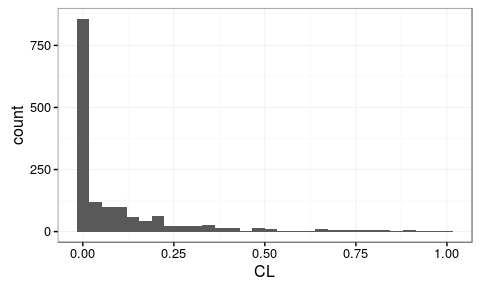

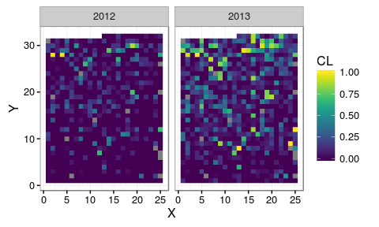

# 1 Models for the binary component

## 1.1 Role of the Basal Circumference

Here we compare several models to take into account the Basal Circumference. It is quite clear that the best model is the one with categories interacting with the Year.

There is a strong jump in the behaviour of resistance for trees under 30 cm of circumference, with respect to those above. However, there is also some variation in the other categories as well.

```
$ref

Call:
c("inla(formula = CL0 ~ 0 + BC + Year2013, family = \"binomial\", ",  "    data = transform(ml$bin_BC$dat, Year2013 = as.numeric(Year == ",  "        2013)), Ntrials = 1, control.compute = list(dic = TRUE, ",  "        waic = TRUE, cpo = TRUE, po = TRUE, config = TRUE), control.fixed = list(expand.factor.strategy = \"inla\"))" )

Time used:
 Pre-processing    Running inla Post-processing           Total
         0.0852          0.0269          0.0000          0.1122

Fixed effects:
             mean     sd 0.025quant 0.5quant 0.975quant    mode kld
BC(0,30    2.6212 0.4608     1.7761   2.5990     3.5881  2.5531   0
BC(30,45   1.4904 0.2354     1.0363   1.4876     1.9605  1.4819   0
BC(45,60   1.0367 0.1357     0.7726   1.0360     1.3050  1.0344   0
BC(60,75   0.8605 0.1036     0.6588   0.8600     1.0652  0.8589   0
BC(75,90   0.6374 0.1198     0.4033   0.6370     0.8736  0.6361   0
BC(90,150  0.9117 0.2196     0.4840   0.9105     1.3456  0.9081   0
Year2013  -1.3778 0.1099    -1.5946  -1.3774    -1.1633 -1.3766   0

The model has no random effects

The model has no hyperparameters

Expected number of effective parameters(std dev): 7.005(0.00)
Number of equivalent replicates : 221.26

Deviance Information Criterion (DIC) ...: 1953.18
Effective number of parameters .........: 6.964

Watanabe-Akaike information criterion (WAIC) ...: 1953.41
Effective number of parameters .................: 7.101

Marginal log-Likelihood:  -1006.66
CPO and PIT are computed

Posterior marginals for linear predictor and fitted values computed


$noBC

Call:
c("inla(formula = ml$bin_BC$fml, family = \"binomial\", data = inla.stack.data(ml$bin_BC$stk), ",  "    Ntrials = 1, control.compute = list(dic = TRUE, waic = TRUE, ",  "        cpo = TRUE, po = TRUE, config = TRUE), control.predictor = list(A = inla.stack.A(ml$bin_BC$stk), ",  "        compute = TRUE, link = 1), control.inla = list(correct = TRUE, ",  "        correct.factor = 10), control.fixed = list(expand.factor.strategy = \"inla\"))" )

Time used:
 Pre-processing    Running inla Post-processing           Total
         0.3987          0.0278          0.0001          0.4266

Fixed effects:
                mean     sd 0.025quant 0.5quant 0.975quant    mode kld
Year.bin2012  1.9432 0.2248     1.5372   1.9307     2.4147  1.9010   0
Year.bin2013 -0.5740 0.1700    -0.9106  -0.5737    -0.2399 -0.5733   0

Random effects:
Name      Model
 theta.bin   SPDE2 model
recode.bin   Generic0 model

Model hyperparameters:
                           mean     sd 0.025quant 0.5quant 0.975quant
Theta1 for theta.bin     0.9625 0.2941     0.4150   0.9500     1.5690
Theta2 for theta.bin     0.9050 0.4076     0.1697   0.8787     1.7644
GroupRho for theta.bin   0.9263 0.1019     0.6381   0.9611     0.9972
Precision for recode.bin 0.2149 0.0551     0.1270   0.2082     0.3419
                           mode
Theta1 for theta.bin     0.9126
Theta2 for theta.bin     0.7983
GroupRho for theta.bin   0.9934
Precision for recode.bin 0.1952

Expected number of effective parameters(std dev): 407.57(33.44)
Number of equivalent replicates : 3.803

Deviance Information Criterion (DIC) ...: 1498.30
Effective number of parameters .........: 356.23

Watanabe-Akaike information criterion (WAIC) ...: 1443.14
Effective number of parameters .................: 248.70

Marginal log-Likelihood:  -988.94
CPO and PIT are computed

Posterior marginals for linear predictor and fitted values computed


$cat

Call:
c("inla(formula = update(ml$bin_BC$fml, ~BC.bin + Year2013.bin + ",  "    . - Year.bin), family = \"binomial\", data = inla.stack.data(ml$bin_BC$stk), ",  "    Ntrials = 1, control.compute = list(dic = TRUE, waic = TRUE, ",  "        cpo = TRUE, po = TRUE, config = TRUE), control.predictor = list(A = inla.stack.A(ml$bin_BC$stk), ",  "        compute = TRUE, link = 1), control.inla = list(correct = TRUE, ",  "        correct.factor = 10), control.fixed = list(expand.factor.strategy = \"inla\"))" )

Time used:
 Pre-processing    Running inla Post-processing           Total
         0.4100          0.0254          0.0003          0.4357

Fixed effects:
                 mean     sd 0.025quant 0.5quant 0.975quant    mode kld
BC.bin(0,30    3.8227 0.8344     2.2919   3.7838     5.5702  3.7049   0
BC.bin(30,45   1.9426 0.4730     1.0516   1.9287     2.9125  1.9009   0
BC.bin(45,60   1.8179 0.2905     1.2787   1.8064     2.4204  1.7823   0
BC.bin(60,75   2.0557 0.2779     1.5531   2.0404     2.6397  2.0055   0
BC.bin(75,90   1.8244 0.2987     1.2740   1.8112     2.4472  1.7831   0
BC.bin(90,150  2.2893 0.4573     1.4293   2.2753     3.2285  2.2470   0
Year2013.bin  -2.6146 0.2562    -3.1506  -2.5996    -2.1538 -2.5620   0

Random effects:
Name      Model
 theta.bin   SPDE2 model
recode.bin   Generic0 model

Model hyperparameters:
                           mean     sd 0.025quant 0.5quant 0.975quant
Theta1 for theta.bin     1.0081 0.3005     0.4509   0.9947     1.6277
Theta2 for theta.bin     0.9112 0.4179     0.1657   0.8817     1.7983
GroupRho for theta.bin   0.9275 0.1068     0.6244   0.9641     0.9974
Precision for recode.bin 0.1929 0.0504     0.1120   0.1870     0.3084
                           mode
Theta1 for theta.bin     0.9547
Theta2 for theta.bin     0.7916
GroupRho for theta.bin   0.9939
Precision for recode.bin 0.1759

Expected number of effective parameters(std dev): 423.16(33.30)
Number of equivalent replicates : 3.663

Deviance Information Criterion (DIC) ...: 1485.01
Effective number of parameters .........: 367.84

Watanabe-Akaike information criterion (WAIC) ...: 1427.51
Effective number of parameters .................: 254.95

Marginal log-Likelihood:  -1006.78
CPO and PIT are computed

Posterior marginals for linear predictor and fitted values computed


$cat2

Call:
c("inla(formula = update(ml$bin_BC$fml, ~. - Year.bin + cut(CIRCOL.bin, ",  "    breaks = c(0, 30, 150)):Year.bin), family = \"binomial\", data = inla.stack.data(ml$bin_BC$stk), ",  "    Ntrials = 1, control.compute = list(dic = TRUE, waic = TRUE, ",  "        cpo = TRUE, po = TRUE, config = TRUE), control.predictor = list(A = inla.stack.A(ml$bin_BC$stk), ",  "        compute = TRUE, link = 1), control.inla = list(correct = TRUE, ",  "        correct.factor = 10), control.fixed = list(expand.factor.strategy = \"inla\"))" )
```

```
Time used:
 Pre-processing    Running inla Post-processing           Total
         0.4122          0.0182          0.0000          0.4304

Fixed effects:
                                                               mean     sd
Year.bin2012:cut(CIRCOL.bin, breaks = c(0, 30, 150))(0,30    2.8686 1.1036
Year.bin2013:cut(CIRCOL.bin, breaks = c(0, 30, 150))(0,30    1.5781 0.8477
Year.bin2012:cut(CIRCOL.bin, breaks = c(0, 30, 150))(30,150  1.9246 0.2308
Year.bin2013:cut(CIRCOL.bin, breaks = c(0, 30, 150))(30,150 -0.6719 0.1758
                                                            0.025quant
Year.bin2012:cut(CIRCOL.bin, breaks = c(0, 30, 150))(0,30       0.9064
Year.bin2013:cut(CIRCOL.bin, breaks = c(0, 30, 150))(0,30       0.0084
Year.bin2012:cut(CIRCOL.bin, breaks = c(0, 30, 150))(30,150     1.5089
Year.bin2013:cut(CIRCOL.bin, breaks = c(0, 30, 150))(30,150    -1.0224
                                                            0.5quant
Year.bin2012:cut(CIRCOL.bin, breaks = c(0, 30, 150))(0,30     2.7937
Year.bin2013:cut(CIRCOL.bin, breaks = c(0, 30, 150))(0,30     1.5426
Year.bin2012:cut(CIRCOL.bin, breaks = c(0, 30, 150))(30,150   1.9114
Year.bin2013:cut(CIRCOL.bin, breaks = c(0, 30, 150))(30,150  -0.6707
                                                            0.975quant
Year.bin2012:cut(CIRCOL.bin, breaks = c(0, 30, 150))(0,30       5.2429
Year.bin2013:cut(CIRCOL.bin, breaks = c(0, 30, 150))(0,30       3.3440
Year.bin2012:cut(CIRCOL.bin, breaks = c(0, 30, 150))(30,150     2.4097
Year.bin2013:cut(CIRCOL.bin, breaks = c(0, 30, 150))(30,150    -0.3289
                                                               mode kld
Year.bin2012:cut(CIRCOL.bin, breaks = c(0, 30, 150))(0,30    2.6380   0
Year.bin2013:cut(CIRCOL.bin, breaks = c(0, 30, 150))(0,30    1.4703   0
Year.bin2012:cut(CIRCOL.bin, breaks = c(0, 30, 150))(30,150  1.8796   0
Year.bin2013:cut(CIRCOL.bin, breaks = c(0, 30, 150))(30,150 -0.6686   0

Random effects:
Name      Model
 theta.bin   SPDE2 model
recode.bin   Generic0 model

Model hyperparameters:
                           mean     sd 0.025quant 0.5quant 0.975quant
Theta1 for theta.bin     0.9451 0.2949     0.3934   0.9336     1.5513
Theta2 for theta.bin     0.8883 0.4123     0.1465   0.8611     1.7577
GroupRho for theta.bin   0.9290 0.1016     0.6417   0.9637     0.9974
Precision for recode.bin 0.2027 0.0534     0.1186   0.1958     0.3263
                           mode
Theta1 for theta.bin     0.8987
Theta2 for theta.bin     0.7776
GroupRho for theta.bin   0.9937
Precision for recode.bin 0.1825

Expected number of effective parameters(std dev): 415.63(33.68)
Number of equivalent replicates : 3.729

Deviance Information Criterion (DIC) ...: 1487.71
Effective number of parameters .........: 361.71

Watanabe-Akaike information criterion (WAIC) ...: 1432.03
Effective number of parameters .................: 251.94

Marginal log-Likelihood:  -992.33
CPO and PIT are computed

Posterior marginals for linear predictor and fitted values computed


$catxyear

Call:
c("inla(formula = update(ml$bin_BC$fml, ~. - Year.bin + Year.bin:BC.bin), ",  "    family = \"binomial\", data = inla.stack.data(ml$bin_BC$stk), ",  "    Ntrials = 1, control.compute = list(dic = TRUE, waic = TRUE, ",  "        cpo = TRUE, po = TRUE, config = TRUE), control.predictor = list(A = inla.stack.A(ml$bin_BC$stk), ",  "        compute = TRUE, link = 1), control.inla = list(correct = TRUE, ",  "        correct.factor = 10), control.fixed = list(expand.factor.strategy = \"inla\"))" )

Time used:
 Pre-processing    Running inla Post-processing           Total
         0.4376          0.0183          0.0000          0.4559

Fixed effects:
                              mean     sd 0.025quant 0.5quant 0.975quant
Year.bin2012:BC.bin(0,30    3.0177 1.1638     0.9487   2.9388     5.5219
Year.bin2013:BC.bin(0,30    1.6514 0.9048    -0.0232   1.6132     3.5375
Year.bin2012:BC.bin(30,45   2.2986 0.6776     1.0496   2.2690     3.7127
Year.bin2013:BC.bin(30,45  -0.8274 0.5200    -1.8664  -0.8221     0.1808
Year.bin2012:BC.bin(45,60   1.9311 0.3635     1.2590   1.9160     2.6855
Year.bin2013:BC.bin(45,60  -0.8543 0.2970    -1.4549  -0.8485    -0.2861
Year.bin2012:BC.bin(60,75   2.1902 0.3185     1.6130   2.1737     2.8550
Year.bin2013:BC.bin(60,75  -0.6039 0.2524    -1.1043  -0.6028    -0.1098
Year.bin2012:BC.bin(75,90   1.9342 0.3489     1.2925   1.9185     2.6604
Year.bin2013:BC.bin(75,90  -0.8511 0.3234    -1.5019  -0.8461    -0.2285
Year.bin2012:BC.bin(90,150  2.0824 0.5536     1.0439   2.0645     3.2221
Year.bin2013:BC.bin(90,150 -0.0472 0.5314    -1.1033  -0.0439     0.9891
                              mode kld
Year.bin2012:BC.bin(0,30    2.7753   0
Year.bin2013:BC.bin(0,30    1.5356   0
Year.bin2012:BC.bin(30,45   2.2089   0
Year.bin2013:BC.bin(30,45  -0.8116   0
Year.bin2012:BC.bin(45,60   1.8835   0
Year.bin2013:BC.bin(45,60  -0.8367   0
Year.bin2012:BC.bin(60,75   2.1333   0
Year.bin2013:BC.bin(60,75  -0.6008   0
Year.bin2012:BC.bin(75,90   1.8839   0
Year.bin2013:BC.bin(75,90  -0.8360   0
Year.bin2012:BC.bin(90,150  2.0285   0
Year.bin2013:BC.bin(90,150 -0.0372   0

Random effects:
Name      Model
 theta.bin   SPDE2 model
recode.bin   Generic0 model

Model hyperparameters:
                           mean     sd 0.025quant 0.5quant 0.975quant
Theta1 for theta.bin     1.0762 0.2987     0.5190   1.0647     1.6893
Theta2 for theta.bin     0.8867 0.4209     0.1373   0.8565     1.7814
GroupRho for theta.bin   0.9287 0.1054     0.6304   0.9647     0.9973
Precision for recode.bin 0.1684 0.0489     0.0969   0.1601     0.2865
                           mode
Theta1 for theta.bin     1.0302
Theta2 for theta.bin     0.7640
GroupRho for theta.bin   0.9937
Precision for recode.bin 0.1444

Expected number of effective parameters(std dev): 446.23(34.27)
Number of equivalent replicates : 3.474

Deviance Information Criterion (DIC) ...: 1471.60
Effective number of parameters .........: 385.50

Watanabe-Akaike information criterion (WAIC) ...: 1409.64
Effective number of parameters .................: 263.75
```

```
Marginal log-Likelihood:  -1025.32
CPO and PIT are computed

Posterior marginals for linear predictor and fitted values computed


$lin

Call:
c("inla(formula = update(ml$bin_BC$fml, ~circ.sc.bin + .), family = \"binomial\", ",  "    data = inla.stack.data(ml$bin_BC$stk), Ntrials = 1, control.compute = list(dic = TRUE, ",  "        waic = TRUE, cpo = TRUE, po = TRUE, config = TRUE), control.predictor = list(A = inla.stack.A(ml$bin_BC$stk), ",  "        compute = TRUE, link = 1), control.inla = list(correct = TRUE, ",  "        correct.factor = 10), control.fixed = list(expand.factor.strategy = \"inla\"))" )

Time used:
 Pre-processing    Running inla Post-processing           Total
         0.4187          0.0271          0.0001          0.4459

Fixed effects:
                mean     sd 0.025quant 0.5quant 0.975quant    mode kld
BC.sc.bin    -0.1101 0.1262    -0.3611  -0.1092     0.1356 -0.1074   0
Year.bin2012  1.9441 0.2279     1.5333   1.9312     2.4231  1.9004   0
Year.bin2013 -0.6079 0.1745    -0.9539  -0.6074    -0.2654 -0.6068   0

Random effects:
Name      Model
 theta.bin   SPDE2 model
recode.bin   Generic0 model

Model hyperparameters:
                           mean     sd 0.025quant 0.5quant 0.975quant
Theta1 for theta.bin     0.9509 0.2992     0.3905   0.9395     1.5652
Theta2 for theta.bin     0.8956 0.4129     0.1485   0.8698     1.7643
GroupRho for theta.bin   0.9283 0.1022     0.6389   0.9632     0.9973
Precision for recode.bin 0.2064 0.0533     0.1211   0.1999     0.3292
                           mode
Theta1 for theta.bin     0.9050
Theta2 for theta.bin     0.7913
GroupRho for theta.bin   0.9935
Precision for recode.bin 0.1876

Expected number of effective parameters(std dev): 413.12(33.32)
Number of equivalent replicates : 3.752

Deviance Information Criterion (DIC) ...: 1494.22
Effective number of parameters .........: 360.57

Watanabe-Akaike information criterion (WAIC) ...: 1437.81
Effective number of parameters .................: 250.78

Marginal log-Likelihood:  -993.96
CPO and PIT are computed

Posterior marginals for linear predictor and fitted values computed


$quad

Call:
c("inla(formula = update(ml$bin_BC$fml, ~circ.sc.bin + I(circ.sc.bin^2) + ",  "    .), family = \"binomial\", data = inla.stack.data(ml$bin_BC$stk), ",  "    Ntrials = 1, control.compute = list(dic = TRUE, waic = TRUE, ",  "        cpo = TRUE, po = TRUE, config = TRUE), control.predictor = list(A = inla.stack.A(ml$bin_BC$stk), ",  "        compute = TRUE, link = 1), control.inla = list(correct = TRUE, ",  "        correct.factor = 10), control.fixed = list(expand.factor.strategy = \"inla\"))" )

Time used:
 Pre-processing    Running inla Post-processing           Total
         0.4289          0.0214          0.0000          0.4503

Fixed effects:
                  mean     sd 0.025quant 0.5quant 0.975quant    mode kld
BC.sc.bin      -0.0864 0.1273    -0.3394  -0.0856     0.1618 -0.0840   0
I(BC.sc.bin^2)  0.1587 0.0759     0.0131   0.1574     0.3115  0.1550   0
Year.bin2012    1.7714 0.2363     1.3417   1.7591     2.2670  1.7313   0
Year.bin2013   -0.7950 0.1965    -1.1876  -0.7933    -0.4127 -0.7900   0

Random effects:
Name      Model
 theta.bin   SPDE2 model
recode.bin   Generic0 model

Model hyperparameters:
                           mean     sd 0.025quant 0.5quant 0.975quant
Theta1 for theta.bin     0.9186 0.2991     0.3583   0.9072     1.5324
Theta2 for theta.bin     0.8937 0.4157     0.1434   0.8671     1.7692
GroupRho for theta.bin   0.9270 0.1059     0.6263   0.9633     0.9973
Precision for recode.bin 0.2042 0.0535     0.1194   0.1974     0.3277
                           mode
Theta1 for theta.bin     0.8728
Theta2 for theta.bin     0.7857
GroupRho for theta.bin   0.9935
Precision for recode.bin 0.1845

Expected number of effective parameters(std dev): 414.21(33.60)
Number of equivalent replicates : 3.742

Deviance Information Criterion (DIC) ...: 1491.59
Effective number of parameters .........: 361.19

Watanabe-Akaike information criterion (WAIC) ...: 1435.59
Effective number of parameters .................: 251.47

Marginal log-Likelihood:  -997.91
CPO and PIT are computed

Posterior marginals for linear predictor and fitted values computed


$np

Call:
c("inla(formula = update(ml$bin_BC$fml, ~f(cut(circ.sc.bin, 51), ",  "    model = \"rw2\", scale.model = TRUE, hyper = list(theta = prec.A)) + ",  "    .), family = \"binomial\", data = inla.stack.data(ml$bin_BC$stk), ",  "    Ntrials = 1, control.compute = list(dic = TRUE, waic = TRUE, ",  "        cpo = TRUE, po = TRUE, config = TRUE), control.predictor = list(A = inla.stack.A(ml$bin_BC$stk), ",  "        compute = TRUE, link = 1), control.inla = list(correct = TRUE, ",  "        correct.factor = 10), control.fixed = list(expand.factor.strategy = \"inla\"))" )

Time used:
 Pre-processing    Running inla Post-processing           Total
         0.4299          0.0179          0.0001          0.4479

Fixed effects:
                mean     sd 0.025quant 0.5quant 0.975quant    mode kld
Year.bin2012  2.2691 0.2814     1.7556   2.2553     2.8602  2.2271   0
Year.bin2013 -0.2840 0.2246    -0.7231  -0.2853     0.1619 -0.2877   0

Random effects:
Name      Model
 cut(BC.sc.bin, 51)   RW2 model
theta.bin   SPDE2 model
recode.bin   Generic0 model

Model hyperparameters:
                                     mean     sd 0.025quant 0.5quant
Precision for cut(circ.sc.bin, 51) 2.4084 1.9690     0.3452   1.8865
Theta1 for theta.bin               0.8848 0.2863     0.3551   0.8714
Theta2 for theta.bin               0.8491 0.4055     0.1323   0.8180
GroupRho for theta.bin             0.9239 0.1042     0.6275   0.9596
Precision for recode.bin           0.2090 0.0538     0.1234   0.2023
                                   0.975quant   mode
Precision for cut(circ.sc.bin, 51)     7.5362 0.9629
Theta1 for theta.bin                   1.4764 0.8311
Theta2 for theta.bin                   1.7129 0.7209
GroupRho for theta.bin                 0.9972 0.9937
Precision for recode.bin               0.3331 0.1895
```

```
Expected number of effective parameters(std dev): 412.49(33.18)
Number of equivalent replicates : 3.758

Deviance Information Criterion (DIC) ...: 1494.10
Effective number of parameters .........: 359.83

Watanabe-Akaike information criterion (WAIC) ...: 1438.38
Effective number of parameters .................: 250.78

Marginal log-Likelihood:  -1127.03
CPO and PIT are computed

Posterior marginals for linear predictor and fitted values computed
```

|  | DIC | p_D | WAIC | p_W | marginal_loglik | LPML |
| --- | --- | --- | --- | --- | --- | --- |
| ref | 1953 | 7 | 1953 | 7 | -1007 | -977 |
| noBC | 1498 | 356 | 1443 | 249 | -989 | -738 |
| cat | 1485 | 368 | 1428 | 255 | -1007 | -732 |
| cat2 | 1488 | 362 | 1432 | 252 | -992 | -733 |
| catxyear | 1472 | 386 | 1410 | 264 | -1025 | -725 |
| lin | 1494 | 361 | 1438 | 251 | -994 | -736 |
| quad | 1492 | 361 | 1436 | 251 | -998 | -735 |
| np | 1494 | 360 | 1438 | 251 | -1127 | -736 |

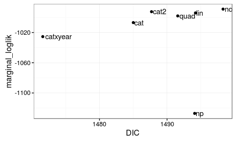

Relative performance of models. The reference model without genetic and spatio-temporal effects is off the scale.

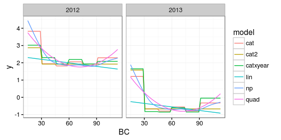

Baseline effect of the Basal Circumference by Year and model in the latent scale.

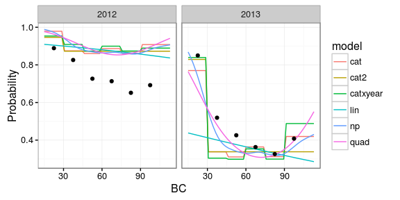

Baseline effect of the Basal Circumference by Year and model in the probability scale. The black dots are the observed proportions of zeros.

In conclusion, the BC variable seems to explain part of the binary component of CL. The main conclusion being that smaller trees have higher chance of escaping or resisting the disease.

However, BC is in turn explained in part by local environmental conditions. I.e. trees grow less on dryer areas, which are coincidentally bad conditions for the spread of the fungi. So the question arises to whether bad environmental condition causes less growth which in turn increases the chance of resisting the disease, or in reality bad environmental conditions causes **both** less growth and and increase in escaping the disease.

In fact, we see that while the models including the BC variable have lower DICs, the model without the variable have higher likelihood. This can be a result of a lack of separability between the spatial effect and the BC covariate.

Sice it is hard to find a biological relationship between BC and CL escaping/resisting, we stick to the theory that the local environmental conditions are the underlying cause of the apparent relationship. In consequence, **we do not include** this variable in the model.

## 1.2 Role of the Provenance

Here we test the relevance of the Provenance in explaining the Binary component.

While the DIC suggests using the main effect of the provenance of the covariate, the marginal likelihood of the model without provenance is somewhat larger. Furthermore, the sizes of the effects are very small. Thus, we consider that if there is some effect of the provenance then it must be very weak, and we choose not to use it in the model.

```
$ref

Call:
c("inla(formula = CL0 ~ 0 + PROV + Year2013, family = \"binomial\", ",  "    data = ml$bin_PROV$dat, Ntrials = 1, control.compute = list(dic = TRUE, ",  "        waic = TRUE, cpo = TRUE, po = TRUE, config = TRUE), control.fixed = list(expand.factor.strategy = \"inla\"), ",  "    inla.call = \"submit\")")

Time used:
 Pre-processing    Running inla Post-processing           Total
         0.1893          0.0419          0.0000          0.2312

Fixed effects:
            mean     sd 0.025quant 0.5quant 0.975quant    mode kld
PROVa     1.0287 0.1130     0.8088   1.0280     1.2523  1.0267   0
PROVc     0.8239 0.1005     0.6280   0.8233     1.0224  0.8223   0
PROVv     0.8176 0.1206     0.5824   0.8170     1.0557  0.8159   0
Year2013 -1.3196 0.1079    -1.5325  -1.3193    -1.1088 -1.3186   0

The model has no random effects

The model has no hyperparameters

Expected number of effective parameters(std dev): 4.006(0.00)
Number of equivalent replicates : 386.95

Deviance Information Criterion (DIC) ...: 1980.00
Effective number of parameters .........: 3.999

Watanabe-Akaike information criterion (WAIC) ...: 1980.03
Effective number of parameters .................: 4.009

Marginal log-Likelihood:  -1009.13
CPO and PIT are computed

Posterior marginals for linear predictor and fitted values computed


$noPROV

Call:
c("inla(formula = ml$bin_PROV$fml, family = \"binomial\", data = inla.stack.data(ml$bin_PROV$stk), ",  "    Ntrials = 1, control.compute = list(dic = TRUE, waic = TRUE, ",  "        cpo = TRUE, po = TRUE, config = TRUE), control.predictor = list(A = inla.stack.A(ml$bin_PROV$stk), ",  "        compute = TRUE, link = 1), control.inla = list(correct = TRUE, ",  "        correct.factor = 10), control.fixed = list(expand.factor.strategy = \"inla\"), ",  "    inla.call = \"submit\")")

Time used:
 Pre-processing    Running inla Post-processing           Total
         0.6182          0.0303          0.0000          0.6486

Fixed effects:
                mean     sd 0.025quant 0.5quant 0.975quant    mode kld
Year.bin2012  1.9496 0.2244     1.5446   1.9371     2.4205  1.9071   0
Year.bin2013 -0.5681 0.1689    -0.9022  -0.5678    -0.2361 -0.5675   0

Random effects:
Name      Model
 theta.bin   SPDE2 model
recode.bin   Generic0 model

Model hyperparameters:
                           mean     sd 0.025quant 0.5quant 0.975quant
Theta1 for theta.bin     0.9576 0.2930     0.4134   0.9447     1.5626
Theta2 for theta.bin     0.9022 0.4067     0.1707   0.8753     1.7605
GroupRho for theta.bin   0.9265 0.1026     0.6372   0.9616     0.9972
Precision for recode.bin 0.2148 0.0550     0.1268   0.2081     0.3415
                           mode
Theta1 for theta.bin     0.9061
Theta2 for theta.bin     0.7926
GroupRho for theta.bin   0.9934
Precision for recode.bin 0.1953

Expected number of effective parameters(std dev): 407.60(33.43)
Number of equivalent replicates : 3.803

Deviance Information Criterion (DIC) ...: 1498.27
Effective number of parameters .........: 356.25

Watanabe-Akaike information criterion (WAIC) ...: 1443.09
Effective number of parameters .................: 248.71

Marginal log-Likelihood:  -987.04
CPO and PIT are computed

Posterior marginals for linear predictor and fitted values computed


$cat

Call:
c("inla(formula = update(ml$bin_PROV$fml, ~PROV.bin + Year2013.bin + ",  "    . - Year.bin), family = \"binomial\", data = inla.stack.data(ml$bin_PROV$stk), ",  "    Ntrials = 1, control.compute = list(dic = TRUE, waic = TRUE, ",  "        cpo = TRUE, po = TRUE, config = TRUE), control.predictor = list(A = inla.stack.A(ml$bin_PROV$stk), ",  "        compute = TRUE, link = 1), control.inla = list(correct = TRUE, ",  "        correct.factor = 10), control.fixed = list(expand.factor.strategy = \"inla\"), ",  "    inla.call = \"submit\")")

Time used:
 Pre-processing    Running inla Post-processing           Total
         0.4085          0.0310          0.0000          0.4395

Fixed effects:
                mean     sd 0.025quant 0.5quant 0.975quant    mode kld
PROV.bina     2.0815 0.4502     1.2414   2.0647     3.0152  2.0312   0
PROV.binc     1.7683 0.3954     1.0298   1.7538     2.5876  1.7248   0
PROV.binv     2.1066 0.4841     1.2020   2.0889     3.1096  2.0537   0
Year2013.bin -2.5499 0.2470    -3.0636  -2.5372    -2.1030 -2.5055   0

Random effects:
Name      Model
 theta.bin   SPDE2 model
recode.bin   Generic0 model

Model hyperparameters:
                           mean     sd 0.025quant 0.5quant 0.975quant
Theta1 for theta.bin     0.9595 0.2961     0.4087   0.9468     1.5705
Theta2 for theta.bin     0.9159 0.4100     0.1780   0.8889     1.7812
GroupRho for theta.bin   0.9283 0.1029     0.6366   0.9634     0.9973
Precision for recode.bin 0.1961 0.0504     0.1149   0.1902     0.3118
                           mode
Theta1 for theta.bin     0.9085
Theta2 for theta.bin     0.8061
GroupRho for theta.bin   0.9935
Precision for recode.bin 0.1790

Expected number of effective parameters(std dev): 419.87(32.87)
Number of equivalent replicates : 3.692

Deviance Information Criterion (DIC) ...: 1492.51
Effective number of parameters .........: 366.11

Watanabe-Akaike information criterion (WAIC) ...: 1434.15
Effective number of parameters .................: 253.20

Marginal log-Likelihood:  -997.07
CPO and PIT are computed

Posterior marginals for linear predictor and fitted values computed


$catxyear

Call:
c("inla(formula = update(ml$bin_PROV$fml, ~. - Year.bin + Year.bin:PROV.bin), ",  "    family = \"binomial\", data = inla.stack.data(ml$bin_PROV$stk), ",  "    Ntrials = 1, control.compute = list(dic = TRUE, waic = TRUE, ",  "        cpo = TRUE, po = TRUE, config = TRUE), control.predictor = list(A = inla.stack.A(ml$bin_PROV$stk), ",  "        compute = TRUE, link = 1), control.inla = list(correct = TRUE, ",  "        correct.factor = 10), control.fixed = list(expand.factor.strategy = \"inla\"), ",  "    inla.call = \"submit\")")

Time used:
 Pre-processing    Running inla Post-processing           Total
         0.4199          0.0310          0.0000          0.4510

Fixed effects:
                          mean     sd 0.025quant 0.5quant 0.975quant
Year.bin2012:PROV.bina  1.9659 0.4599     1.1037   1.9503     2.9161
Year.bin2013:PROV.bina -0.3708 0.4287    -1.2240  -0.3682     0.4672
Year.bin2012:PROV.binc  1.7958 0.4052     1.0387   1.7812     2.6352
Year.bin2013:PROV.binc -0.8154 0.3809    -1.5827  -0.8095    -0.0808
Year.bin2012:PROV.binv  2.1990 0.5037     1.2585   2.1806     3.2426
Year.bin2013:PROV.binv -0.5278 0.4668    -1.4588  -0.5242     0.3826
                          mode kld
Year.bin2012:PROV.bina  1.9192   0
Year.bin2013:PROV.bina -0.3630   0
Year.bin2012:PROV.binc  1.7518   0
Year.bin2013:PROV.binc -0.7981   0
Year.bin2012:PROV.binv  2.1437   0
Year.bin2013:PROV.binv -0.5172   0

Random effects:
Name      Model
 theta.bin   SPDE2 model
recode.bin   Generic0 model

Model hyperparameters:
                           mean     sd 0.025quant 0.5quant 0.975quant
Theta1 for theta.bin     0.9865 0.3042     0.4168   0.9748     1.6106
Theta2 for theta.bin     0.9375 0.4126     0.1841   0.9142     1.7986
GroupRho for theta.bin   0.9206 0.1136     0.5954   0.9597     0.9971
Precision for recode.bin 0.1980 0.0514     0.1147   0.1922     0.3149
                           mode
Theta1 for theta.bin     0.9398
Theta2 for theta.bin     0.8444
GroupRho for theta.bin   0.9931
Precision for recode.bin 0.1815

Expected number of effective parameters(std dev): 420.46(33.29)
Number of equivalent replicates : 3.687

Deviance Information Criterion (DIC) ...: 1498.29
Effective number of parameters .........: 366.55

Watanabe-Akaike information criterion (WAIC) ...: 1440.89
Effective number of parameters .................: 254.37

Marginal log-Likelihood:  -1006.48
CPO and PIT are computed

Posterior marginals for linear predictor and fitted values computed
```

|  | DIC | p_D | WAIC | p_W | marginal_loglik | LPML |
| --- | --- | --- | --- | --- | --- | --- |
| ref | 1980 | 4 | 1980 | 4 | -1009 | -990 |
| noPROV | 1498 | 356 | 1443 | 249 | -987 | -738 |
| cat | 1493 | 366 | 1434 | 253 | -997 | -735 |
| catxyear | 1498 | 367 | 1441 | 254 | -1006 | -738 |

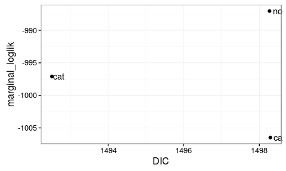

Relative performance of models. The reference model without genetic and spatio-temporal effects is off the scale.

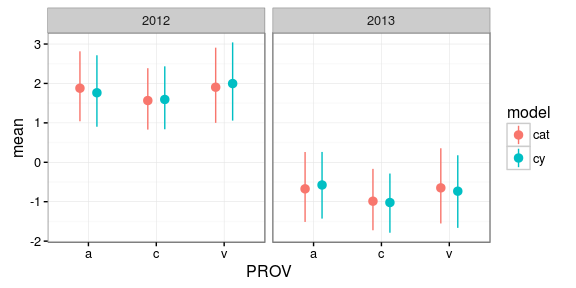

Baseline effect of the Provenance by Year and model in the latent scale.

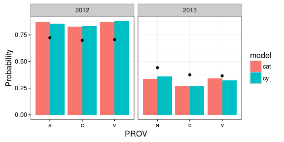

Baseline effect of the Provenance by Year and model in the probability scale. The black dots are the observed proportions of zeros.

## 1.3 Role of the Bud-flush

Here we test the relevance of the Bud-flush in explaining the Binary component.

```
$ref

Call:
c("inla(formula = CL0 ~ 0 + BF98 + Year2013, family = \"binomial\", ",  "    data = ml$bin_BF$dat, Ntrials = 1, control.compute = list(dic = TRUE, ",  "        waic = TRUE, cpo = TRUE, po = TRUE, config = TRUE), control.fixed = list(expand.factor.strategy = \"inla\"), ",  "    inla.call = \"submit\")")

Time used:
 Pre-processing    Running inla Post-processing           Total
         0.1745          0.0391          0.0000          0.2137

Fixed effects:
            mean     sd 0.025quant 0.5quant 0.975quant    mode kld
BF981     1.2268 0.3487     0.5562   1.2220     1.9253  1.2123   0
BF982     1.0337 0.2140     0.6177   1.0322     1.4576  1.0293   0
BF983     0.8937 0.1465     0.6082   0.8929     1.1829  0.8915   0
BF984     0.9779 0.1208     0.7427   0.9773     1.2168  0.9759   0
BF985     0.8144 0.0969     0.6255   0.8139     1.0058  0.8129   0
Year2013 -1.3203 0.1076    -1.5327  -1.3199    -1.1101 -1.3192   0

The model has no random effects

The model has no hyperparameters

Expected number of effective parameters(std dev): 6.005(0.00)
Number of equivalent replicates : 258.10

Deviance Information Criterion (DIC) ...: 1982.05
Effective number of parameters .........: 5.98

Watanabe-Akaike information criterion (WAIC) ...: 1982.17
Effective number of parameters .................: 6.05

Marginal log-Likelihood:  -1017.45
CPO and PIT are computed

Posterior marginals for linear predictor and fitted values computed


$noBF

Call:
c("inla(formula = ml$bin_BF$fml, family = \"binomial\", data = inla.stack.data(ml$bin_BF$stk), ",  "    Ntrials = 1, control.compute = list(dic = TRUE, waic = TRUE, ",  "        cpo = TRUE, po = TRUE, config = TRUE), control.predictor = list(A = inla.stack.A(ml$bin_BF$stk), ",  "        compute = TRUE, link = 1), control.inla = list(correct = TRUE, ",  "        correct.factor = 10), control.fixed = list(expand.factor.strategy = \"inla\"), ",  "    inla.call = \"submit\")")

Time used:
 Pre-processing    Running inla Post-processing           Total
         0.4505          0.0363          0.0000          0.4868

Fixed effects:
                mean     sd 0.025quant 0.5quant 0.975quant    mode kld
Year.bin2012  1.9496 0.2244     1.5446   1.9371     2.4205  1.9071   0
Year.bin2013 -0.5681 0.1689    -0.9022  -0.5678    -0.2361 -0.5675   0

Random effects:
Name      Model
 theta.bin   SPDE2 model
recode.bin   Generic0 model

Model hyperparameters:
                           mean     sd 0.025quant 0.5quant 0.975quant
Theta1 for theta.bin     0.9576 0.2930     0.4134   0.9447     1.5626
Theta2 for theta.bin     0.9022 0.4067     0.1707   0.8753     1.7605
GroupRho for theta.bin   0.9265 0.1026     0.6372   0.9616     0.9972
Precision for recode.bin 0.2148 0.0550     0.1268   0.2081     0.3415
                           mode
Theta1 for theta.bin     0.9061
Theta2 for theta.bin     0.7926
GroupRho for theta.bin   0.9934
Precision for recode.bin 0.1953

Expected number of effective parameters(std dev): 407.60(33.43)
Number of equivalent replicates : 3.803

Deviance Information Criterion (DIC) ...: 1498.27
Effective number of parameters .........: 356.25

Watanabe-Akaike information criterion (WAIC) ...: 1443.09
Effective number of parameters .................: 248.71

Marginal log-Likelihood:  -987.04
CPO and PIT are computed

Posterior marginals for linear predictor and fitted values computed


$cat

Call:
c("inla(formula = update(ml$bin_BF$fml, ~BF98.bin + Year2013.bin + ",  "    . - Year.bin), family = \"binomial\", data = inla.stack.data(ml$bin_BF$stk), ",  "    Ntrials = 1, control.compute = list(dic = TRUE, waic = TRUE, ",  "        cpo = TRUE, po = TRUE, config = TRUE), control.predictor = list(A = inla.stack.A(ml$bin_BF$stk), ",  "        compute = TRUE, link = 1), control.inla = list(correct = TRUE, ",  "        correct.factor = 10), control.fixed = list(expand.factor.strategy = \"inla\"), ",  "    inla.call = \"submit\")")

Time used:
 Pre-processing    Running inla Post-processing           Total
         0.4980          0.0384          0.0001          0.5365

Fixed effects:
                mean     sd 0.025quant 0.5quant 0.975quant    mode kld
BF98.bin1     3.0785 0.7206     1.7279   3.0546     4.5636  3.0066   0
BF98.bin2     2.4501 0.4744     1.5663   2.4324     3.4322  2.3960   0
BF98.bin3     1.7656 0.3238     1.1601   1.7544     2.4338  1.7312   0
BF98.bin4     1.9241 0.2908     1.3891   1.9110     2.5303  1.8827   0
BF98.bin5     1.9451 0.2621     1.4678   1.9317     2.4939  1.9014   0
Year2013.bin -2.5747 0.2531    -3.1004  -2.5616    -2.1174 -2.5286   0

Random effects:
Name      Model
 theta.bin   SPDE2 model
recode.bin   Generic0 model

Model hyperparameters:
                           mean     sd 0.025quant 0.5quant 0.975quant
Theta1 for theta.bin     0.9763 0.2940     0.4281   0.9640     1.5821
Theta2 for theta.bin     0.9129 0.4140     0.1696   0.8851     1.7873
GroupRho for theta.bin   0.9292 0.1006     0.6449   0.9635     0.9973
Precision for recode.bin 0.1905 0.0500     0.1108   0.1844     0.3059
                           mode
Theta1 for theta.bin     0.9273
Theta2 for theta.bin     0.7996
GroupRho for theta.bin   0.9936
Precision for recode.bin 0.1727

Expected number of effective parameters(std dev): 424.74(33.01)
Number of equivalent replicates : 3.649

Deviance Information Criterion (DIC) ...: 1487.90
Effective number of parameters .........: 369.74

Watanabe-Akaike information criterion (WAIC) ...: 1428.92
Effective number of parameters .................: 255.21

Marginal log-Likelihood:  -1004.42
CPO and PIT are computed

Posterior marginals for linear predictor and fitted values computed


$catxyear

Call:
c("inla(formula = update(ml$bin_BF$fml, ~. - Year.bin + Year.bin:BF98.bin), ",  "    family = \"binomial\", data = inla.stack.data(ml$bin_BF$stk), ",  "    Ntrials = 1, control.compute = list(dic = TRUE, waic = TRUE, ",  "        cpo = TRUE, po = TRUE, config = TRUE), control.predictor = list(A = inla.stack.A(ml$bin_BF$stk), ",  "        compute = TRUE, link = 1), control.inla = list(correct = TRUE, ",  "        correct.factor = 10), control.fixed = list(expand.factor.strategy = \"inla\"), ",  "    inla.call = \"submit\")")

Time used:
 Pre-processing    Running inla Post-processing           Total
         0.4877          0.0409          0.0000          0.5286

Fixed effects:
                          mean     sd 0.025quant 0.5quant 0.975quant
Year.bin2012:BF98.bin1  2.7886 0.8685     1.1783   2.7536     4.5952
Year.bin2013:BF98.bin1  0.8045 0.7701    -0.6886   0.7968     2.3418
Year.bin2012:BF98.bin2  2.3924 0.5702     1.3339   2.3698     3.5769
Year.bin2013:BF98.bin2  0.0125 0.5016    -0.9747   0.0123     0.9996
Year.bin2012:BF98.bin3  2.2634 0.4085     1.5125   2.2447     3.1172
Year.bin2013:BF98.bin3 -1.1961 0.3580    -1.9276  -1.1863    -0.5192
Year.bin2012:BF98.bin4  1.8291 0.3235     1.2323   1.8149     2.5034
Year.bin2013:BF98.bin4 -0.5072 0.2759    -1.0565  -0.5052     0.0302
Year.bin2012:BF98.bin5  2.0084 0.2901     1.4850   1.9917     2.6200
Year.bin2013:BF98.bin5 -0.6265 0.2325    -1.0920  -0.6239    -0.1758
                          mode kld
Year.bin2012:BF98.bin1  2.6831   0
Year.bin2013:BF98.bin1  0.7823   0
Year.bin2012:BF98.bin2  2.3245   0
Year.bin2013:BF98.bin2  0.0122   0
Year.bin2012:BF98.bin3  2.2060   0
Year.bin2013:BF98.bin3 -1.1672   0
Year.bin2012:BF98.bin4  1.7854   0
Year.bin2013:BF98.bin4 -0.5012   0
Year.bin2012:BF98.bin5  1.9539   0
Year.bin2013:BF98.bin5 -0.6189   0

Random effects:
Name      Model
 theta.bin   SPDE2 model
recode.bin   Generic0 model

Model hyperparameters:
                           mean     sd 0.025quant 0.5quant 0.975quant
Theta1 for theta.bin     0.9866 0.2709     0.4880   0.9732     1.5482
Theta2 for theta.bin     0.8907 0.4128     0.1661   0.8579     1.7724
GroupRho for theta.bin   0.8968 0.1507     0.4543   0.9507     0.9967
Precision for recode.bin 0.1823 0.0499     0.0993   0.1778     0.2933
                           mode
Theta1 for theta.bin     0.9326
Theta2 for theta.bin     0.7555
GroupRho for theta.bin   0.9925
Precision for recode.bin 0.1696

Expected number of effective parameters(std dev): 433.58(34.49)
Number of equivalent replicates : 3.575

Deviance Information Criterion (DIC) ...: 1485.21
Effective number of parameters .........: 376.98

Watanabe-Akaike information criterion (WAIC) ...: 1424.28
Effective number of parameters .................: 258.82

Marginal log-Likelihood:  -1018.82
CPO and PIT are computed

Posterior marginals for linear predictor and fitted values computed
```

|  | DIC | WAIC | marginal_loglik | LPML |
| --- | --- | --- | --- | --- |
| ref | 1982 | 1982 | -1017 | -991 |
| noBF | 1498 | 1443 | -987 | -738 |
| cat | 1488 | 1429 | -1004 | -733 |
| catxyear | 1485 | 1424 | -1020 | -731 |

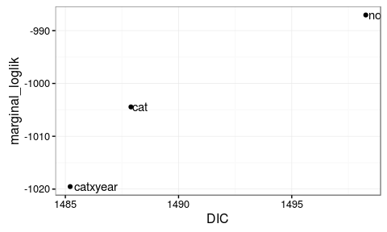

Relative performance of models. The reference model without genetic and spatio-temporal effects is off the scale.

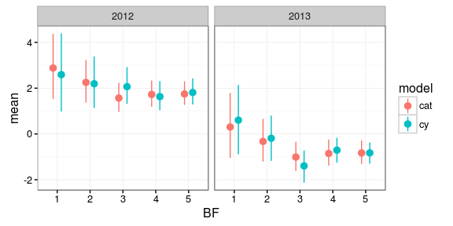

Baseline effect of the Bud flush by Year and model in the latent scale.

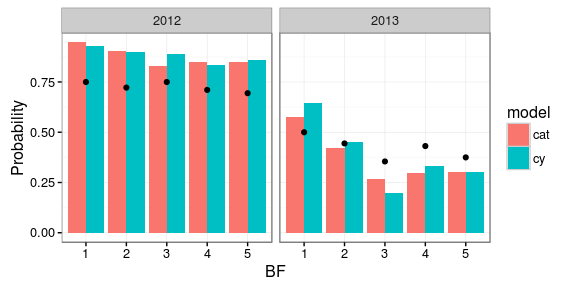

Baseline effect of the Bud flush by Year and model in the probability scale. The black dots are the observed proportions of zeros.

As a conclusion, while there seems to be a trend in the relationship between the binary component and the BF, it is not strong enough to justify contemplating a variable that is more naturally linked to the crown than to the base. Therefore, we choose **not to include** this variable in the model.

## 1.4 Model selection binary component

We have analysed the effects of the Basal Circumference (BC), the Provenance (PROV) and the Bud-flushing (BF) separately. In all three cases the estimated effects are small and the marginal likelihood is highest for the model without the variable included in any form. On the other hand, the other scores are optimal on one of the other models.

In the case of BC we hypothesize a confusion with the spatial effect. The PROV is clearly not relevant. Finally, the BF seems to be somewhat related, but it is hard to justify biologically.

Based on this measures and on the effects sizes we make a preliminary variable selection as follows:

- include the BC variable in its categorical form and its interaction with the year
- do not include the PROV variable
- do not consider the BF variable

Now we compare these three selected submodels (only the one with BC do not coincide with the null), with the null model (not including any of those variables) and with the *full* model (including both BC and BF).

```
$null

Call:
c("inla(formula = ml$bin_BC$fml, family = \"binomial\", data = inla.stack.data(ml$bin_BC$stk), ",  "    Ntrials = 1, control.compute = list(dic = TRUE, waic = TRUE, ",  "        cpo = TRUE, po = TRUE, config = TRUE), control.predictor = list(A = inla.stack.A(ml$bin_BC$stk), ",  "        compute = TRUE, link = 1), control.inla = list(correct = TRUE, ",  "        correct.factor = 10), control.fixed = list(expand.factor.strategy = \"inla\"))" )

Time used:
 Pre-processing    Running inla Post-processing           Total
         0.3987          0.0278          0.0001          0.4266

Fixed effects:
                mean     sd 0.025quant 0.5quant 0.975quant    mode kld
Year.bin2012  1.9432 0.2248     1.5372   1.9307     2.4147  1.9010   0
Year.bin2013 -0.5740 0.1700    -0.9106  -0.5737    -0.2399 -0.5733   0

Random effects:
Name      Model
 theta.bin   SPDE2 model
recode.bin   Generic0 model

Model hyperparameters:
                           mean     sd 0.025quant 0.5quant 0.975quant
Theta1 for theta.bin     0.9625 0.2941     0.4150   0.9500     1.5690
Theta2 for theta.bin     0.9050 0.4076     0.1697   0.8787     1.7644
GroupRho for theta.bin   0.9263 0.1019     0.6381   0.9611     0.9972
Precision for recode.bin 0.2149 0.0551     0.1270   0.2082     0.3419
                           mode
Theta1 for theta.bin     0.9126
Theta2 for theta.bin     0.7983
GroupRho for theta.bin   0.9934
Precision for recode.bin 0.1952

Expected number of effective parameters(std dev): 407.57(33.44)
Number of equivalent replicates : 3.803

Deviance Information Criterion (DIC) ...: 1498.30
Effective number of parameters .........: 356.23

Watanabe-Akaike information criterion (WAIC) ...: 1443.14
Effective number of parameters .................: 248.70

Marginal log-Likelihood:  -988.94
CPO and PIT are computed

Posterior marginals for linear predictor and fitted values computed


$BC

Call:
c("inla(formula = update(ml$bin_BC$fml, ~. - Year.bin + Year.bin:BC.bin), ",  "    family = \"binomial\", data = inla.stack.data(ml$bin_BC$stk), ",  "    Ntrials = 1, control.compute = list(dic = TRUE, waic = TRUE, ",  "        cpo = TRUE, po = TRUE, config = TRUE), control.predictor = list(A = inla.stack.A(ml$bin_BC$stk), ",  "        compute = TRUE, link = 1), control.inla = list(correct = TRUE, ",  "        correct.factor = 10), control.fixed = list(expand.factor.strategy = \"inla\"))" )

Time used:
 Pre-processing    Running inla Post-processing           Total
         0.4376          0.0183          0.0000          0.4559

Fixed effects:
                              mean     sd 0.025quant 0.5quant 0.975quant
Year.bin2012:BC.bin(0,30    3.0177 1.1638     0.9487   2.9388     5.5219
Year.bin2013:BC.bin(0,30    1.6514 0.9048    -0.0232   1.6132     3.5375
Year.bin2012:BC.bin(30,45   2.2986 0.6776     1.0496   2.2690     3.7127
Year.bin2013:BC.bin(30,45  -0.8274 0.5200    -1.8664  -0.8221     0.1808
Year.bin2012:BC.bin(45,60   1.9311 0.3635     1.2590   1.9160     2.6855
Year.bin2013:BC.bin(45,60  -0.8543 0.2970    -1.4549  -0.8485    -0.2861
Year.bin2012:BC.bin(60,75   2.1902 0.3185     1.6130   2.1737     2.8550
Year.bin2013:BC.bin(60,75  -0.6039 0.2524    -1.1043  -0.6028    -0.1098
Year.bin2012:BC.bin(75,90   1.9342 0.3489     1.2925   1.9185     2.6604
Year.bin2013:BC.bin(75,90  -0.8511 0.3234    -1.5019  -0.8461    -0.2285
Year.bin2012:BC.bin(90,150  2.0824 0.5536     1.0439   2.0645     3.2221
Year.bin2013:BC.bin(90,150 -0.0472 0.5314    -1.1033  -0.0439     0.9891
                              mode kld
Year.bin2012:BC.bin(0,30    2.7753   0
Year.bin2013:BC.bin(0,30    1.5356   0
Year.bin2012:BC.bin(30,45   2.2089   0
Year.bin2013:BC.bin(30,45  -0.8116   0
Year.bin2012:BC.bin(45,60   1.8835   0
Year.bin2013:BC.bin(45,60  -0.8367   0
Year.bin2012:BC.bin(60,75   2.1333   0
Year.bin2013:BC.bin(60,75  -0.6008   0
Year.bin2012:BC.bin(75,90   1.8839   0
Year.bin2013:BC.bin(75,90  -0.8360   0
Year.bin2012:BC.bin(90,150  2.0285   0
Year.bin2013:BC.bin(90,150 -0.0372   0

Random effects:
Name      Model
 theta.bin   SPDE2 model
recode.bin   Generic0 model

Model hyperparameters:
                           mean     sd 0.025quant 0.5quant 0.975quant
Theta1 for theta.bin     1.0762 0.2987     0.5190   1.0647     1.6893
Theta2 for theta.bin     0.8867 0.4209     0.1373   0.8565     1.7814
GroupRho for theta.bin   0.9287 0.1054     0.6304   0.9647     0.9973
Precision for recode.bin 0.1684 0.0489     0.0969   0.1601     0.2865
                           mode
Theta1 for theta.bin     1.0302
Theta2 for theta.bin     0.7640
GroupRho for theta.bin   0.9937
Precision for recode.bin 0.1444

Expected number of effective parameters(std dev): 446.23(34.27)
Number of equivalent replicates : 3.474

Deviance Information Criterion (DIC) ...: 1471.60
Effective number of parameters .........: 385.50

Watanabe-Akaike information criterion (WAIC) ...: 1409.64
Effective number of parameters .................: 263.75

Marginal log-Likelihood:  -1025.32
CPO and PIT are computed

Posterior marginals for linear predictor and fitted values computed


$BF

Call:
c("inla(formula = update(ml$bin_BC$fml, ~BC.bin + Year2013.bin + ",  "    . - Year.bin), family = \"binomial\", data = inla.stack.data(ml$bin_BC$stk), ",  "    Ntrials = 1, control.compute = list(dic = TRUE, waic = TRUE, ",  "        cpo = TRUE, po = TRUE, config = TRUE), control.predictor = list(A = inla.stack.A(ml$bin_BC$stk), ",  "        compute = TRUE, link = 1), control.inla = list(correct = TRUE, ",  "        correct.factor = 10), control.fixed = list(expand.factor.strategy = \"inla\"))" )

Time used:
 Pre-processing    Running inla Post-processing           Total
         0.4100          0.0254          0.0003          0.4357

Fixed effects:
                 mean     sd 0.025quant 0.5quant 0.975quant    mode kld
BC.bin(0,30    3.8227 0.8344     2.2919   3.7838     5.5702  3.7049   0
BC.bin(30,45   1.9426 0.4730     1.0516   1.9287     2.9125  1.9009   0
BC.bin(45,60   1.8179 0.2905     1.2787   1.8064     2.4204  1.7823   0
BC.bin(60,75   2.0557 0.2779     1.5531   2.0404     2.6397  2.0055   0
BC.bin(75,90   1.8244 0.2987     1.2740   1.8112     2.4472  1.7831   0
BC.bin(90,150  2.2893 0.4573     1.4293   2.2753     3.2285  2.2470   0
Year2013.bin  -2.6146 0.2562    -3.1506  -2.5996    -2.1538 -2.5620   0

Random effects:
Name      Model
 theta.bin   SPDE2 model
recode.bin   Generic0 model

Model hyperparameters:
                           mean     sd 0.025quant 0.5quant 0.975quant
Theta1 for theta.bin     1.0081 0.3005     0.4509   0.9947     1.6277
Theta2 for theta.bin     0.9112 0.4179     0.1657   0.8817     1.7983
GroupRho for theta.bin   0.9275 0.1068     0.6244   0.9641     0.9974
Precision for recode.bin 0.1929 0.0504     0.1120   0.1870     0.3084
                           mode
Theta1 for theta.bin     0.9547
Theta2 for theta.bin     0.7916
GroupRho for theta.bin   0.9939
Precision for recode.bin 0.1759

Expected number of effective parameters(std dev): 423.16(33.30)
Number of equivalent replicates : 3.663

Deviance Information Criterion (DIC) ...: 1485.01
Effective number of parameters .........: 367.84

Watanabe-Akaike information criterion (WAIC) ...: 1427.51
Effective number of parameters .................: 254.95

Marginal log-Likelihood:  -1006.78
CPO and PIT are computed

Posterior marginals for linear predictor and fitted values computed


$full

Call:
c("inla(formula = update(ml$bin_msel$fml, ~BF_2.bin + BF_3.bin + ",  "    BF_4.bin + BF_5.bin + Year.bin:BC.bin + . - Year.bin), family = \"binomial\", ",  "    data = inla.stack.data(ml$bin_msel$stk), Ntrials = 1, control.compute = list(dic = TRUE, ",  "        waic = TRUE, cpo = TRUE, po = TRUE, config = TRUE), control.predictor = list(A = inla.stack.A(ml$bin_msel$stk), ",  "        compute = TRUE, link = 1), control.inla = list(correct = TRUE, ",  "        correct.factor = 10), control.fixed = list(expand.factor.strategy = \"inla\"), ",  "    inla.call = \"submit\")")

Time used:
 Pre-processing    Running inla Post-processing           Total
         0.5670          0.0387          0.0000          0.6058

Fixed effects:
                              mean     sd 0.025quant 0.5quant 0.975quant
BF_2.bin                    0.0585 0.6964    -1.3121   0.0577     1.4320
BF_3.bin                   -0.7234 0.6265    -1.9814  -0.7154     0.4888
BF_4.bin                   -0.5808 0.6055    -1.7936  -0.5743     0.5939
BF_5.bin                   -0.5376 0.5943    -1.7268  -0.5316     0.6165
Year.bin2012:BC.bin(0,30    3.5847 1.3007     1.2608   3.5015     6.3718
Year.bin2013:BC.bin(0,30    2.1669 1.0523     0.2156   2.1239     4.3580
Year.bin2012:BC.bin(30,45   2.8971 0.8964     1.2332   2.8615     4.7620
Year.bin2013:BC.bin(30,45  -0.3515 0.7551    -1.8421  -0.3506     1.1321
Year.bin2012:BC.bin(45,60   2.5271 0.6803     1.2567   2.5025     3.9373
Year.bin2013:BC.bin(45,60  -0.3557 0.6263    -1.5979  -0.3531     0.8701
Year.bin2012:BC.bin(60,75   2.8214 0.6755     1.5687   2.7937     4.2294
Year.bin2013:BC.bin(60,75  -0.0646 0.6187    -1.2754  -0.0676     1.1617
Year.bin2012:BC.bin(75,90   2.5124 0.6817     1.2418   2.4867     3.9282
Year.bin2013:BC.bin(75,90  -0.3564 0.6399    -1.6209  -0.3552     0.9001
Year.bin2012:BC.bin(90,150  2.6846 0.8158     1.1467   2.6605     4.3607
Year.bin2013:BC.bin(90,150  0.4667 0.7742    -1.0493   0.4635     1.9991
                              mode kld
BF_2.bin                    0.0561   0
BF_3.bin                   -0.7003   0
BF_4.bin                   -0.5619   0
BF_5.bin                   -0.5202   0
Year.bin2012:BC.bin(0,30    3.3308   0
Year.bin2013:BC.bin(0,30    2.0380   0
Year.bin2012:BC.bin(30,45   2.7913   0
Year.bin2013:BC.bin(30,45  -0.3488   0
Year.bin2012:BC.bin(45,60   2.4542   0
Year.bin2013:BC.bin(45,60  -0.3478   0
Year.bin2012:BC.bin(60,75   2.7388   0
Year.bin2013:BC.bin(60,75  -0.0729   0
Year.bin2012:BC.bin(75,90   2.4365   0
Year.bin2013:BC.bin(75,90  -0.3526   0
Year.bin2012:BC.bin(90,150  2.6140   0
Year.bin2013:BC.bin(90,150  0.4577   0

Random effects:
Name      Model
 theta.bin   SPDE2 model
recode.bin   Generic0 model

Model hyperparameters:
                           mean     sd 0.025quant 0.5quant 0.975quant
Theta1 for theta.bin     1.0736 0.3036     0.5060   1.0617     1.6974
Theta2 for theta.bin     0.8859 0.4115     0.1440   0.8598     1.7520
GroupRho for theta.bin   0.9355 0.0924     0.6763   0.9667     0.9975
Precision for recode.bin 0.1509 0.0432     0.0825   0.1455     0.2508
                           mode
Theta1 for theta.bin     1.0258
Theta2 for theta.bin     0.7794
GroupRho for theta.bin   0.9940
Precision for recode.bin 0.1354

Expected number of effective parameters(std dev): 458.26(33.42)
Number of equivalent replicates : 3.382

Deviance Information Criterion (DIC) ...: 1461.79
Effective number of parameters .........: 394.66

Watanabe-Akaike information criterion (WAIC) ...: 1397.59
Effective number of parameters .................: 268.24

Marginal log-Likelihood:  -1039.44
CPO and PIT are computed

Posterior marginals for linear predictor and fitted values computed
```

|  | DIC | WAIC | marginal_loglik | LPML |
| --- | --- | --- | --- | --- |
| null | 1498 | 1443 | -989 | -738 |
| BC | 1472 | 1410 | -1025 | -725 |
| BF | 1485 | 1428 | -1007 | -732 |
| full | 1462 | 1398 | -1040 | -721 |

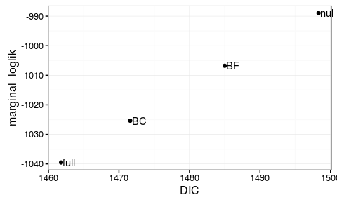

Relative performance of models for the binary component.

We find an antagonistic relationship between two selection criteria. Based on previous observations, we suspect that this is an effect of a lack of identifiability in the model. Therefore, we choose not to include these explanatory variables in the binary component of the model.

# 2 Models for the continuous component

We perform a preliminary likelihood evaluation, to assess whether the data is better fitted using a Beta or a Gamma likelihood.

Both optios have their limitations. The Beta distribution does not admit values of 1 (that are arbitrarily switched to 0.98 here). On the other hand, the Gamma has a semi-infinite support (while we know that there is a maximum at 1 which can eventually accumulate probability mass).

|  | DIC | p_D | WAIC | p_W | marginal_loglik | LPML |
| --- | --- | --- | --- | --- | --- | --- |
| beta | -603 | 26 | -607 | 20 | 184 | 304 |
| gamma | -771 | 26 | -767 | 28 | 262 | 383 |

The results clearly favour the Gamma distribution.

In the following models we include an overdispersion term in the latent space. This is simply unstructured noise, with mean zero and variance $\sigma^2_{\text{od}}$. On exchange, we fix a very high precision for the likelihood distribution.

In this way, we include the distribution-specific variance in the observations scale by an additional random component in the latent scale. This equivalent formulation helps in the specification of a prior distribution for its variance, and facilitates the computation of the heritability.

On the downside, using this trick we loose the ability to compare the models using DIC or WAIC. They are all the same as a consequence of fixing the precision of the likelihood.

Update: step-back from this strategy. I can save it for the final model. For model comparison is more convenient to have access to all measures of model fit. Even if the prior on the precision of the likelihood is approximate, it is the same for all models, so that the comparison is fair. On the other hand, it is not that difficult to assess. The scale should be also around the unit. Therefore, we can safely use the same prior that we were using for the precision of the latent overdispersion parameter.

## 2.1 Role of the Basal Circumference

Here we compare several models to take into account the Basal Circumference. It is quite clear that the best model is the one with categories interacting with the Year.

There is a strong jump in the behaviour of resistance for trees under 30 cm of circumference, with respect to those above. However, there is also some variation in the other categories as well.

```
$ref

Call:
c("inla(formula = yt ~ 0 + BC + Year2013, family = \"gamma\", data = ml$cont$dat, ",  "    control.compute = list(dic = TRUE, waic = TRUE, cpo = TRUE, ",  "        po = TRUE, config = TRUE), control.fixed = list(expand.factor.strategy = \"inla\"), ",  "    inla.call = \"submit\")")

Time used:
 Pre-processing    Running inla Post-processing           Total
         0.1441          0.0411          0.0000          0.1852

Fixed effects:
             mean     sd 0.025quant 0.5quant 0.975quant    mode kld
BC(0,30   -1.0483 0.3558    -1.6908  -1.0690    -0.2920 -1.1121   0
BC(30,45  -1.5068 0.1603    -1.8107  -1.5107    -1.1806 -1.5187   0
BC(45,60  -1.6745 0.0885    -1.8455  -1.6755    -1.4980 -1.6774   0
BC(60,75  -1.6027 0.0712    -1.7407  -1.6034    -1.4611 -1.6047   0
BC(75,90  -1.8183 0.0768    -1.9669  -1.8191    -1.6653 -1.8206   0
BC(90,150 -1.6727 0.1388    -1.9373  -1.6755    -1.3916 -1.6813   0
Year2013   0.1930 0.0706     0.0534   0.1934     0.3308  0.1940   0

The model has no random effects

Model hyperparameters:
                                                mean     sd 0.025quant
Precision parameter for the Gamma observations 1.328 0.0645      1.205
                                               0.5quant 0.975quant  mode
Precision parameter for the Gamma observations    1.327      1.459 1.325

Expected number of effective parameters(std dev): 7.015(6e-04)
Number of equivalent replicates : 99.07

Deviance Information Criterion (DIC) ...: -771.56
Effective number of parameters .........: 7.645

Watanabe-Akaike information criterion (WAIC) ...: -769.51
Effective number of parameters .................: 9.159

Marginal log-Likelihood:  346.83
CPO and PIT are computed

Posterior marginals for linear predictor and fitted values computed


$noBC

Call:
c("inla(formula = ml$cont$fml, family = \"gamma\", data = inla.stack.data(ml$cont$stk), ",  "    control.compute = list(dic = TRUE, waic = TRUE, cpo = TRUE, ",  "        po = TRUE, config = TRUE), control.predictor = list(A = inla.stack.A(ml$cont$stk), ",  "        compute = TRUE, link = 1), control.family = list(hyper = list(theta = prec.od)), ",  "    control.inla = list(h = 0.005), control.fixed = list(expand.factor.strategy = \"inla\"), ",  "    inla.call = \"submit\")")

Time used:
 Pre-processing    Running inla Post-processing           Total
         0.5201          0.0438          0.0001          0.5640

Fixed effects:
                 mean     sd 0.025quant 0.5quant 0.975quant    mode kld
Year.cont2012 -2.1664 0.0735    -2.3103  -2.1669    -2.0203 -2.1677   0
Year.cont2013 -1.8188 0.0548    -1.9253  -1.8194    -1.7085 -1.8206   0

Random effects:
Name      Model
 theta.cont   SPDE2 model
recode.cont   Generic0 model

Model hyperparameters:
                                                  mean     sd 0.025quant
Precision parameter for the Gamma observations  2.9432 0.2624     2.4556
Theta1 for theta.cont                          -0.5910 0.3356    -1.2405
Theta2 for theta.cont                           0.9397 0.6447    -0.2871
GroupRho for theta.cont                         0.6667 0.3079    -0.1806
Precision for recode.cont                       1.8730 0.2383     1.4616
                                               0.5quant 0.975quant    mode
Precision parameter for the Gamma observations   2.9345     3.4852  2.9200
Theta1 for theta.cont                           -0.5947     0.0779 -0.6055
Theta2 for theta.cont                            0.9234     2.2453  0.8755
GroupRho for theta.cont                          0.7676     0.9782  0.9428
Precision for recode.cont                        1.8525     2.3961  1.8079

Expected number of effective parameters(std dev): 293.49(21.05)
Number of equivalent replicates : 2.368

Deviance Information Criterion (DIC) ...: -1144.39
Effective number of parameters .........: 288.99

Watanabe-Akaike information criterion (WAIC) ...: -1138.18
Effective number of parameters .................: 231.59

Marginal log-Likelihood:  330.60
CPO and PIT are computed

Posterior marginals for linear predictor and fitted values computed


$cat

Call:
c("inla(formula = update(ml$cont$fml, ~BC.cont + Year2013.cont + ",  "    . - Year.cont), family = \"gamma\", data = inla.stack.data(ml$cont$stk), ",  "    control.compute = list(dic = TRUE, waic = TRUE, cpo = TRUE, ",  "        po = TRUE, config = TRUE), control.predictor = list(A = inla.stack.A(ml$cont$stk), ",  "        compute = TRUE, link = 1), control.family = list(hyper = list(theta = prec.od)), ",  "    control.fixed = list(expand.factor.strategy = \"inla\"), inla.call = \"submit\")" )

Time used:
 Pre-processing    Running inla Post-processing           Total
         0.5538          0.0445          0.0001          0.5984

Fixed effects:
                  mean     sd 0.025quant 0.5quant 0.975quant    mode kld
BC.cont(0,30   -1.9192 0.4044    -2.6982  -1.9246    -1.1096 -1.9353   0
BC.cont(30,45  -1.9068 0.1900    -2.2785  -1.9073    -1.5326 -1.9083   0
BC.cont(45,60  -2.1884 0.1028    -2.3899  -2.1886    -1.9859 -2.1890   0
BC.cont(60,75  -2.1084 0.0869    -2.2794  -2.1084    -1.9376 -2.1084   0
BC.cont(75,90  -2.3152 0.0952    -2.5030  -2.3151    -2.1285 -2.3147   0
BC.cont(90,150 -2.1190 0.1554    -2.4227  -2.1196    -1.8127 -2.1206   0
Year2013.cont   0.3323 0.0683     0.1960   0.3329     0.4654  0.3342   0

Random effects:
Name      Model
 theta.cont   SPDE2 model
recode.cont   Generic0 model

Model hyperparameters:
                                                  mean     sd 0.025quant
Precision parameter for the Gamma observations  2.9211 0.2625     2.4298
Theta1 for theta.cont                          -0.5496 0.3460    -1.1983
Theta2 for theta.cont                           1.0977 0.5898    -0.0032
GroupRho for theta.cont                         0.6581 0.3092    -0.1855
Precision for recode.cont                       1.9270 0.2495     1.4922
                                               0.5quant 0.975quant    mode
Precision parameter for the Gamma observations   2.9135     3.4603  2.9023
Theta1 for theta.cont                           -0.5623     0.1592 -0.6004
Theta2 for theta.cont                            1.0747     2.3101  1.0061
GroupRho for theta.cont                          0.7574     0.9769  0.9384
Precision for recode.cont                        1.9077     2.4694  1.8669
```

```
Expected number of effective parameters(std dev): 292.26(21.64)
Number of equivalent replicates : 2.378

Deviance Information Criterion (DIC) ...: -1139.84
Effective number of parameters .........: 287.80

Watanabe-Akaike information criterion (WAIC) ...: -1133.38
Effective number of parameters .................: 231.07

Marginal log-Likelihood:  308.09
CPO and PIT are computed

Posterior marginals for linear predictor and fitted values computed


$cat2

Call:
c("inla(formula = update(ml$cont$fml, ~. - Year.cont + cut(CIRCOL.cont, ",  "    breaks = c(0, 30, 150)):Year.cont), family = \"gamma\", data = inla.stack.data(ml$cont$stk), ",  "    control.compute = list(dic = TRUE, waic = TRUE, cpo = TRUE, ",  "        po = TRUE, config = TRUE), control.predictor = list(A = inla.stack.A(ml$cont$stk), ",  "        compute = TRUE, link = 1), control.family = list(hyper = list(theta = prec.od)), ",  "    control.fixed = list(expand.factor.strategy = \"inla\"), inla.call = \"submit\")" )

Time used:
 Pre-processing    Running inla Post-processing           Total
         0.7324          0.0431          0.0000          0.7756

Fixed effects:
                                                                 mean
Year.cont2012:cut(CIRCOL.cont, breaks = c(0, 30, 150))(0,30   -1.1955
Year.cont2013:cut(CIRCOL.cont, breaks = c(0, 30, 150))(0,30   -1.9923
Year.cont2012:cut(CIRCOL.cont, breaks = c(0, 30, 150))(30,150 -2.1829
Year.cont2013:cut(CIRCOL.cont, breaks = c(0, 30, 150))(30,150 -1.8207
                                                                  sd
Year.cont2012:cut(CIRCOL.cont, breaks = c(0, 30, 150))(0,30   0.5909
Year.cont2013:cut(CIRCOL.cont, breaks = c(0, 30, 150))(0,30   0.4344
Year.cont2012:cut(CIRCOL.cont, breaks = c(0, 30, 150))(30,150 0.0740
Year.cont2013:cut(CIRCOL.cont, breaks = c(0, 30, 150))(30,150 0.0548
                                                              0.025quant
Year.cont2012:cut(CIRCOL.cont, breaks = c(0, 30, 150))(0,30      -2.3092
Year.cont2013:cut(CIRCOL.cont, breaks = c(0, 30, 150))(0,30      -2.8232
Year.cont2012:cut(CIRCOL.cont, breaks = c(0, 30, 150))(30,150    -2.3286
Year.cont2013:cut(CIRCOL.cont, breaks = c(0, 30, 150))(30,150    -1.9277
                                                              0.5quant
Year.cont2012:cut(CIRCOL.cont, breaks = c(0, 30, 150))(0,30    -1.2128
Year.cont2013:cut(CIRCOL.cont, breaks = c(0, 30, 150))(0,30    -2.0001
Year.cont2012:cut(CIRCOL.cont, breaks = c(0, 30, 150))(30,150  -2.1831
Year.cont2013:cut(CIRCOL.cont, breaks = c(0, 30, 150))(30,150  -1.8213
                                                              0.975quant
Year.cont2012:cut(CIRCOL.cont, breaks = c(0, 30, 150))(0,30       0.0159
Year.cont2013:cut(CIRCOL.cont, breaks = c(0, 30, 150))(0,30      -1.1164
Year.cont2012:cut(CIRCOL.cont, breaks = c(0, 30, 150))(30,150    -2.0368
Year.cont2013:cut(CIRCOL.cont, breaks = c(0, 30, 150))(30,150    -1.7108
                                                                 mode kld
Year.cont2012:cut(CIRCOL.cont, breaks = c(0, 30, 150))(0,30   -1.2481   0
Year.cont2013:cut(CIRCOL.cont, breaks = c(0, 30, 150))(0,30   -2.0158   0
Year.cont2012:cut(CIRCOL.cont, breaks = c(0, 30, 150))(30,150 -2.1833   0
Year.cont2013:cut(CIRCOL.cont, breaks = c(0, 30, 150))(30,150 -1.8223   0

Random effects:
Name      Model
 theta.cont   SPDE2 model
recode.cont   Generic0 model

Model hyperparameters:
                                                  mean     sd 0.025quant
Precision parameter for the Gamma observations  2.9548 0.2640     2.4637
Theta1 for theta.cont                          -0.5859 0.3384    -1.2404
Theta2 for theta.cont                           0.9737 0.6447    -0.2482
GroupRho for theta.cont                         0.6304 0.3249    -0.2425
Precision for recode.cont                       1.8784 0.2370     1.4648
                                               0.5quant 0.975quant    mode
Precision parameter for the Gamma observations   2.9463     3.4996  2.9322
Theta1 for theta.cont                           -0.5899     0.0892 -0.6017
Theta2 for theta.cont                            0.9564     2.2819  0.9055
GroupRho for theta.cont                          0.7327     0.9740  0.9296
Precision for recode.cont                        1.8603     2.3928  1.8221

Expected number of effective parameters(std dev): 295.09(20.96)
Number of equivalent replicates : 2.355

Deviance Information Criterion (DIC) ...: -1145.70
Effective number of parameters .........: 290.61

Watanabe-Akaike information criterion (WAIC) ...: -1140.13
Effective number of parameters .................: 232.24

Marginal log-Likelihood:  324.27
CPO and PIT are computed

Posterior marginals for linear predictor and fitted values computed


$catxyear

Call:
c("inla(formula = update(ml$cont$fml, ~. - Year.cont + Year.cont:BC.cont), ",  "    family = \"gamma\", data = inla.stack.data(ml$cont$stk), control.compute = list(dic = TRUE, ",  "        waic = TRUE, cpo = TRUE, po = TRUE, config = TRUE), control.predictor = list(A = inla.stack.A(ml$cont$stk), ",  "        compute = TRUE, link = 1), control.family = list(hyper = list(theta = prec.od)), ",  "    control.fixed = list(expand.factor.strategy = \"inla\"), inla.call = \"submit\")" )

Time used:
 Pre-processing    Running inla Post-processing           Total
         0.5538          0.0420          0.0000          0.5958

Fixed effects:
                                mean     sd 0.025quant 0.5quant 0.975quant
Year.cont2012:BC.cont(0,30   -1.1697 0.5902    -2.2812  -1.1873     0.0413
Year.cont2013:BC.cont(0,30   -1.9689 0.4331    -2.7969  -1.9768    -1.0951
Year.cont2012:BC.cont(30,45  -2.0851 0.2849    -2.6311  -2.0897    -1.5120
Year.cont2013:BC.cont(30,45  -1.5367 0.1858    -1.8985  -1.5379    -1.1691
Year.cont2012:BC.cont(45,60  -2.2323 0.1322    -2.4887  -2.2334    -1.9694
Year.cont2013:BC.cont(45,60  -1.8412 0.0944    -2.0257  -1.8415    -1.6551
Year.cont2012:BC.cont(60,75  -2.1028 0.0997    -2.2978  -2.1031    -1.9061
Year.cont2013:BC.cont(60,75  -1.7817 0.0730    -1.9248  -1.7819    -1.6378
Year.cont2012:BC.cont(75,90  -2.2815 0.1116    -2.5002  -2.2818    -2.0616
Year.cont2013:BC.cont(75,90  -2.0059 0.0911    -2.1844  -2.0060    -1.8264
Year.cont2012:BC.cont(90,150 -2.1881 0.2119    -2.5986  -2.1901    -1.7665
Year.cont2013:BC.cont(90,150 -1.7522 0.1650    -2.0730  -1.7534    -1.4251
                                mode kld
Year.cont2012:BC.cont(0,30   -1.2232   0
Year.cont2013:BC.cont(0,30   -1.9928   0
Year.cont2012:BC.cont(30,45  -2.0989   0
Year.cont2013:BC.cont(30,45  -1.5401   0
Year.cont2012:BC.cont(45,60  -2.2356   0
Year.cont2013:BC.cont(45,60  -1.8421   0
Year.cont2012:BC.cont(60,75  -2.1037   0
Year.cont2013:BC.cont(60,75  -1.7822   0
Year.cont2012:BC.cont(75,90  -2.2823   0
Year.cont2013:BC.cont(75,90  -2.0064   0
Year.cont2012:BC.cont(90,150 -2.1940   0
Year.cont2013:BC.cont(90,150 -1.7557   0
```

```
Random effects:
Name      Model
 theta.cont   SPDE2 model
recode.cont   Generic0 model

Model hyperparameters:
                                                  mean     sd 0.025quant
Precision parameter for the Gamma observations  2.9256 0.2645     2.4311
Theta1 for theta.cont                          -0.4568 0.3786    -1.1789
Theta2 for theta.cont                           1.1981 0.6207     0.0226
GroupRho for theta.cont                         0.6233 0.3173    -0.2179
Precision for recode.cont                       1.9205 0.2491     1.4890
                                               0.5quant 0.975quant    mode
Precision parameter for the Gamma observations   2.9178     3.4694  2.9061
Theta1 for theta.cont                           -0.4662     0.3070 -0.4941
Theta2 for theta.cont                            1.1802     2.4563  1.1273
GroupRho for theta.cont                          0.7182     0.9707  0.9178
Precision for recode.cont                        1.9000     2.4644  1.8560

Expected number of effective parameters(std dev): 297.26(21.64)
Number of equivalent replicates : 2.338

Deviance Information Criterion (DIC) ...: -1135.72
Effective number of parameters .........: 292.74

Watanabe-Akaike information criterion (WAIC) ...: -1130.66
Effective number of parameters .................: 233.60

Marginal log-Likelihood:  286.18
CPO and PIT are computed

Posterior marginals for linear predictor and fitted values computed


$lin

Call:
c("inla(formula = update(ml$cont$fml, ~circ.sc.cont + .), family = \"gamma\", ",  "    data = inla.stack.data(ml$cont$stk), control.compute = list(dic = TRUE, ",  "        waic = TRUE, cpo = TRUE, po = TRUE, config = TRUE), control.predictor = list(A = inla.stack.A(ml$cont$stk), ",  "        compute = TRUE, link = 1), control.family = list(hyper = list(theta = prec.od)), ",  "    control.fixed = list(expand.factor.strategy = \"inla\"), inla.call = \"submit\")" )

Time used:
 Pre-processing    Running inla Post-processing           Total
         0.5284          0.0427          0.0000          0.5711

Fixed effects:
                 mean     sd 0.025quant 0.5quant 0.975quant    mode kld
BC.sc.cont    -0.0641 0.0477    -0.1575  -0.0642     0.0297 -0.0644   0
Year.cont2012 -2.1635 0.0732    -2.3072  -2.1638    -2.0188 -2.1642   0
Year.cont2013 -1.8246 0.0539    -1.9303  -1.8249    -1.7174 -1.8253   0

Random effects:
Name      Model
 theta.cont   SPDE2 model
recode.cont   Generic0 model

Model hyperparameters:
                                                  mean     sd 0.025quant
Precision parameter for the Gamma observations  2.9181 0.2605     2.4300
Theta1 for theta.cont                          -0.5278 0.3553    -1.2038
Theta2 for theta.cont                           1.1057 0.6180    -0.0596
GroupRho for theta.cont                         0.6733 0.2972    -0.1382
Precision for recode.cont                       1.9067 0.2465     1.4839
                                               0.5quant 0.975quant    mode
Precision parameter for the Gamma observations   2.9108     3.4526  2.9003
Theta1 for theta.cont                           -0.5373     0.1921 -0.5656
Theta2 for theta.cont                            1.0863     2.3635  1.0288
GroupRho for theta.cont                          0.7688     0.9777  0.9402
Precision for recode.cont                        1.8845     2.4503  1.8357

Expected number of effective parameters(std dev): 290.97(21.49)
Number of equivalent replicates : 2.389

Deviance Information Criterion (DIC) ...: -1139.81
Effective number of parameters .........: 286.86

Watanabe-Akaike information criterion (WAIC) ...: -1133.11
Effective number of parameters .................: 230.57

Marginal log-Likelihood:  325.00
CPO and PIT are computed

Posterior marginals for linear predictor and fitted values computed


$quad

Call:
c("inla(formula = update(ml$cont$fml, ~circ.sc.cont + I(circ.sc.cont^2) + ",  "    .), family = \"gamma\", data = inla.stack.data(ml$cont$stk), ",  "    control.compute = list(dic = TRUE, waic = TRUE, cpo = TRUE, ",  "        po = TRUE, config = TRUE), control.predictor = list(A = inla.stack.A(ml$cont$stk), ",  "        compute = TRUE, link = 1), control.family = list(hyper = list(theta = prec.od)), ",  "    control.fixed = list(expand.factor.strategy = \"inla\"), inla.call = \"submit\")" )

Time used:
 Pre-processing    Running inla Post-processing           Total
         0.5416          0.0454          0.0000          0.5871

Fixed effects:
                   mean     sd 0.025quant 0.5quant 0.975quant    mode kld
BC.sc.cont      -0.0666 0.0479    -0.1606  -0.0666     0.0277 -0.0667   0
I(BC.sc.cont^2)  0.0364 0.0333    -0.0288   0.0363     0.1020  0.0361   0
Year.cont2012   -2.1978 0.0797    -2.3548  -2.1978    -2.0409 -2.1977   0
Year.cont2013   -1.8601 0.0629    -1.9839  -1.8602    -1.7359 -1.8603   0

Random effects:
Name      Model
 theta.cont   SPDE2 model
recode.cont   Generic0 model

Model hyperparameters:
                                                  mean     sd 0.025quant
Precision parameter for the Gamma observations  2.9259 0.2619     2.4331
Theta1 for theta.cont                          -0.5503 0.3443    -1.2026
Theta2 for theta.cont                           1.0935 0.6098    -0.0472
GroupRho for theta.cont                         0.6549 0.3058    -0.1712
Precision for recode.cont                       1.9031 0.2464     1.4818
                                               0.5quant 0.975quant    mode
Precision parameter for the Gamma observations   2.9194     3.4607  2.9114
Theta1 for theta.cont                           -0.5606     0.1504 -0.5913
Theta2 for theta.cont                            1.0706     2.3453  1.0025
GroupRho for theta.cont                          0.7511     0.9753  0.9330
Precision for recode.cont                        1.8803     2.4475  1.8300

Expected number of effective parameters(std dev): 292.04(21.54)
Number of equivalent replicates : 2.38

Deviance Information Criterion (DIC) ...: -1140.32
Effective number of parameters .........: 288.29
```

```
Watanabe-Akaike information criterion (WAIC) ...: -1134.03
Effective number of parameters .................: 231.27

Marginal log-Likelihood:  318.70
CPO and PIT are computed

Posterior marginals for linear predictor and fitted values computed


$np

Call:
c("inla(formula = update(ml$cont$fml, ~f(cut(circ.sc.cont, 51), ",  "    model = \"rw2\", scale.model = TRUE, hyper = list(theta = prec.A)) + ",  "    .), family = \"gamma\", data = inla.stack.data(ml$cont$stk), ",  "    control.compute = list(dic = TRUE, waic = TRUE, cpo = TRUE, ",  "        po = TRUE, config = TRUE), control.predictor = list(A = inla.stack.A(ml$cont$stk), ",  "        compute = TRUE, link = 1), control.family = list(hyper = list(theta = prec.od)), ",  "    control.fixed = list(expand.factor.strategy = \"inla\"), inla.call = \"submit\")" )

Time used:
 Pre-processing    Running inla Post-processing           Total
         0.5663          0.0419          0.0000          0.6083

Fixed effects:
                 mean     sd 0.025quant 0.5quant 0.975quant    mode kld
Year.cont2012 -2.0521 0.1157    -2.2789  -2.0523    -1.8242 -2.0528   0
Year.cont2013 -1.7141 0.1040    -1.9181  -1.7144    -1.5088 -1.7150   0

Random effects:
Name      Model
 cut(BC.sc.cont, 51)   RW2 model
theta.cont   SPDE2 model
recode.cont   Generic0 model

Model hyperparameters:
                                                  mean     sd 0.025quant
Precision parameter for the Gamma observations  2.9375 0.2628     2.4469
Precision for cut(circ.sc.cont, 51)             3.6227 2.0826     0.9368
Theta1 for theta.cont                          -0.4506 0.3572    -1.1106
Theta2 for theta.cont                           1.2147 0.5384     0.2296
GroupRho for theta.cont                         0.6723 0.3009    -0.1484
Precision for recode.cont                       1.9076 0.2437     1.4838
                                               0.5quant 0.975quant    mode
Precision parameter for the Gamma observations   2.9295     3.4782  2.9172
Precision for cut(circ.sc.cont, 51)              3.1949     8.8214  2.3233
Theta1 for theta.cont                           -0.4684     0.2928 -0.5184
Theta2 for theta.cont                            1.1854     2.3428  1.1041
GroupRho for theta.cont                          0.7688     0.9804  0.9492
Precision for recode.cont                        1.8882     2.4376  1.8469

Expected number of effective parameters(std dev): 294.54(21.49)
Number of equivalent replicates : 2.36

Deviance Information Criterion (DIC) ...: -1143.14
Effective number of parameters .........: 289.75

Watanabe-Akaike information criterion (WAIC) ...: -1136.44
Effective number of parameters .................: 232.52

Marginal log-Likelihood:  189.38
CPO and PIT are computed

Posterior marginals for linear predictor and fitted values computed
```

|  | DIC | p_D | WAIC | p_W | marginal_loglik | LPML |
| --- | --- | --- | --- | --- | --- | --- |
| ref | -772 | 8 | -770 | 9 | 347 | 384 |
| noBC | -1144 | 289 | -1138 | 232 | 331 | 311 |
| cat | -1140 | 288 | -1133 | 231 | 308 | 314 |
| cat2 | -1146 | 291 | -1140 | 232 | 324 | 298 |
| catxyear | -1136 | 293 | -1131 | 234 | 286 | 294 |
| lin | -1140 | 287 | -1133 | 231 | 325 | 317 |
| quad | -1140 | 288 | -1134 | 231 | 319 | 313 |
| np | -1143 | 290 | -1136 | 233 | 190 | 310 |

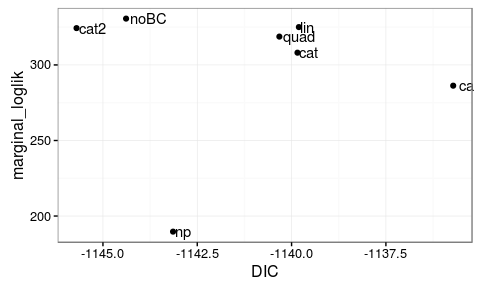

Relative performance of models. The reference model without genetic and spatio-temporal effects is off the scale.

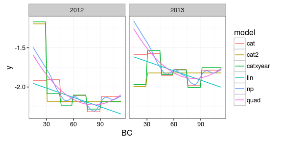

Baseline effect of the Basal Circumference by Year and model in the latent scale.

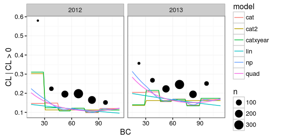

Baseline effect of the Basal Circumference by Year and model in the observed scale. The black dots are the observed mean of CL|CL>0.

## 2.2 Role of the Provenance

Here we test the relevance of the Provenance in explaining the Binary component.

```
$ref

Call:
c("inla(formula = yt ~ 0 + PROV + Year2013, family = \"gamma\", data = ml$cont$dat, ",  "    control.compute = list(dic = TRUE, waic = TRUE, cpo = TRUE, ",  "        po = TRUE, config = TRUE), control.fixed = list(expand.factor.strategy = \"inla\"), ",  "    inla.call = \"submit\")")

Time used:
 Pre-processing    Running inla Post-processing           Total
         0.1519          0.0481          0.0000          0.2000

Fixed effects:
            mean     sd 0.025quant 0.5quant 0.975quant    mode kld
PROVa    -1.6180 0.0784    -1.7697  -1.6187    -1.4620 -1.6202   0
PROVc    -1.6894 0.0692    -1.8234  -1.6900    -1.5516 -1.6913   0
PROVv    -1.6433 0.0816    -1.8013  -1.6441    -1.4808 -1.6458   0
Year2013  0.1820 0.0714     0.0407   0.1823     0.3213  0.1829   0

The model has no random effects

Model hyperparameters:
                                               mean     sd 0.025quant
Precision parameter for the Gamma observations 1.30 0.0628       1.18
                                               0.5quant 0.975quant  mode
Precision parameter for the Gamma observations    1.298      1.427 1.296

Expected number of effective parameters(std dev): 4.015(6e-04)
Number of equivalent replicates : 173.11

Deviance Information Criterion (DIC) ...: -755.84
Effective number of parameters .........: 4.658

Watanabe-Akaike information criterion (WAIC) ...: -755.23
Effective number of parameters .................: 5.203

Marginal log-Likelihood:  351.12
CPO and PIT are computed

Posterior marginals for linear predictor and fitted values computed


$noPROV

Call:
c("inla(formula = ml$cont$fml, family = \"gamma\", data = inla.stack.data(ml$cont$stk), ",  "    control.compute = list(dic = TRUE, waic = TRUE, cpo = TRUE, ",  "        po = TRUE, config = TRUE), control.predictor = list(A = inla.stack.A(ml$cont$stk), ",  "        compute = TRUE, link = 1), control.family = list(hyper = list(theta = prec.od)), ",  "    control.fixed = list(expand.factor.strategy = \"inla\"), inla.call = \"submit\")" )

Time used:
 Pre-processing    Running inla Post-processing           Total
         0.5811          0.0509          0.0001          0.6322

Fixed effects:
                 mean     sd 0.025quant 0.5quant 0.975quant    mode kld
Year.cont2012 -2.1664 0.0731    -2.3093  -2.1668    -2.0211 -2.1677   0
Year.cont2013 -1.8191 0.0543    -1.9246  -1.8197    -1.7100 -1.8209   0

Random effects:
Name      Model
 theta.cont   SPDE2 model
recode.cont   Generic0 model

Model hyperparameters:
                                                  mean     sd 0.025quant
Precision parameter for the Gamma observations  2.9407 0.2619     2.4547
Theta1 for theta.cont                          -0.5767 0.3491    -1.2442
Theta2 for theta.cont                           1.0058 0.6213    -0.1820
GroupRho for theta.cont                         0.6703 0.3075    -0.1781
Precision for recode.cont                       1.8707 0.2372     1.4601
                                               0.5quant 0.975quant    mode
Precision parameter for the Gamma observations   2.9314     3.4829  2.9153
Theta1 for theta.cont                           -0.5845     0.1262 -0.6078
Theta2 for theta.cont                            0.9915     2.2600  0.9491
GroupRho for theta.cont                          0.7718     0.9791  0.9453
Precision for recode.cont                        1.8509     2.3897  1.8078

Expected number of effective parameters(std dev): 293.32(21.10)
Number of equivalent replicates : 2.369

Deviance Information Criterion (DIC) ...: -1144.55
Effective number of parameters .........: 288.49

Watanabe-Akaike information criterion (WAIC) ...: -1138.10
Effective number of parameters .................: 231.41

Marginal log-Likelihood:  330.56
CPO and PIT are computed

Posterior marginals for linear predictor and fitted values computed


$cat

Call:
c("inla(formula = update(ml$cont$fml, ~PROV.cont + Year2013.cont + ",  "    . - Year.cont), family = \"gamma\", data = inla.stack.data(ml$cont$stk), ",  "    control.compute = list(dic = TRUE, waic = TRUE, cpo = TRUE, ",  "        po = TRUE, config = TRUE), control.predictor = list(A = inla.stack.A(ml$cont$stk), ",  "        compute = TRUE, link = 1), control.family = list(hyper = list(theta = prec.od)), ",  "    control.fixed = list(expand.factor.strategy = \"inla\"), inla.call = \"submit\")" )

Time used:
 Pre-processing    Running inla Post-processing           Total
         0.5527          0.0466          0.0000          0.5994

Fixed effects:
                 mean     sd 0.025quant 0.5quant 0.975quant    mode kld
PROV.conta    -2.1020 0.1485    -2.3952  -2.1015    -1.8120 -2.1004   0
PROV.contc    -2.1608 0.1311    -2.4194  -2.1604    -1.9046 -2.1595   0
PROV.contv    -2.1346 0.1604    -2.4512  -2.1341    -1.8211 -2.1330   0
Year2013.cont  0.3226 0.0683     0.1867   0.3231     0.4552  0.3243   0

Random effects:
Name      Model
 theta.cont   SPDE2 model
recode.cont   Generic0 model

Model hyperparameters:
                                                  mean     sd 0.025quant
Precision parameter for the Gamma observations  3.1197 0.2685     2.5771
Theta1 for theta.cont                          -0.7340 0.3287    -1.3600
Theta2 for theta.cont                           0.7089 0.6262    -0.4649
GroupRho for theta.cont                         0.6688 0.3028    -0.1468
Precision for recode.cont                       1.9987 0.2782     1.5421
                                               0.5quant 0.975quant    mode
Precision parameter for the Gamma observations   3.1301     3.6245  3.1749
Theta1 for theta.cont                           -0.7415    -0.0701 -0.7642
Theta2 for theta.cont                            0.6852     1.9927  0.6153
GroupRho for theta.cont                          0.7643     0.9825  0.9571
Precision for recode.cont                        1.9663     2.6271  1.8937

Expected number of effective parameters(std dev): 293.16(17.34)
Number of equivalent replicates : 2.371

Deviance Information Criterion (DIC) ...: -1094.37
Effective number of parameters .........: 315.59

Watanabe-Akaike information criterion (WAIC) ...: -1111.92
Effective number of parameters .................: 234.31

Marginal log-Likelihood:  306.65
CPO and PIT are computed

Posterior marginals for linear predictor and fitted values computed


$catxyear

Call:
c("inla(formula = update(ml$cont$fml, ~. - Year.cont + Year.cont:PROV.cont), ",  "    family = \"gamma\", data = inla.stack.data(ml$cont$stk), control.compute = list(dic = TRUE, ",  "        waic = TRUE, cpo = TRUE, po = TRUE, config = TRUE), control.predictor = list(A = inla.stack.A(ml$cont$stk), ",  "        compute = TRUE, link = 1), control.family = list(hyper = list(theta = prec.od)), ",  "    control.fixed = list(expand.factor.strategy = \"inla\"), inla.call = \"submit\")" )

Time used:
 Pre-processing    Running inla Post-processing           Total
         0.5518          0.0490          0.0001          0.6009

Fixed effects:
                            mean     sd 0.025quant 0.5quant 0.975quant
Year.cont2012:PROV.conta -2.1292 0.1596    -2.4441  -2.1288    -1.8171
Year.cont2013:PROV.conta -1.7637 0.1427    -2.0455  -1.7633    -1.4846
Year.cont2012:PROV.contc -2.1548 0.1392    -2.4298  -2.1542    -1.8828
Year.cont2013:PROV.contc -1.8364 0.1231    -2.0788  -1.8362    -1.5952
Year.cont2012:PROV.contv -2.1812 0.1749    -2.5265  -2.1806    -1.8393
Year.cont2013:PROV.contv -1.7896 0.1552    -2.0954  -1.7894    -1.4856
                            mode kld
Year.cont2012:PROV.conta -2.1279   0
Year.cont2013:PROV.conta -1.7625   0
Year.cont2012:PROV.contc -2.1532   0
Year.cont2013:PROV.contc -1.8358   0
Year.cont2012:PROV.contv -2.1795   0
Year.cont2013:PROV.contv -1.7889   0

Random effects:
Name      Model
 theta.cont   SPDE2 model
recode.cont   Generic0 model

Model hyperparameters:
                                                  mean     sd 0.025quant
Precision parameter for the Gamma observations  2.8212 0.2571     2.3449
Theta1 for theta.cont                          -0.6366 0.3369    -1.2966
Theta2 for theta.cont                           0.8617 0.6671    -0.4282
GroupRho for theta.cont                         0.6599 0.3182    -0.2157
Precision for recode.cont                       1.8522 0.2466     1.4203
                                               0.5quant 0.975quant    mode
Precision parameter for the Gamma observations   2.8119     3.3540  2.7957
Theta1 for theta.cont                           -0.6378     0.0283 -0.6413
Theta2 for theta.cont                            0.8521     2.1947  0.8243
GroupRho for theta.cont                          0.7657     0.9796  0.9472
Precision for recode.cont                        1.8337     2.3875  1.7958

Expected number of effective parameters(std dev): 291.06(21.97)
Number of equivalent replicates : 2.388

Deviance Information Criterion (DIC) ...: -1114.87
Effective number of parameters .........: 285.93

Watanabe-Akaike information criterion (WAIC) ...: -1107.10
Effective number of parameters .................: 231.27

Marginal log-Likelihood:  300.39
CPO and PIT are computed

Posterior marginals for linear predictor and fitted values computed
```

|  | DIC | p_D | WAIC | p_W | marginal_loglik | LPML |
| --- | --- | --- | --- | --- | --- | --- |
| ref | -756 | 5 | -755 | 5 | 351 | 378 |
| noPROV | -1145 | 288 | -1138 | 231 | 331 | 311 |
| cat | -1094 | 316 | -1112 | 234 | 307 | 302 |
| catxyear | -1115 | 286 | -1107 | 231 | 300 | 295 |

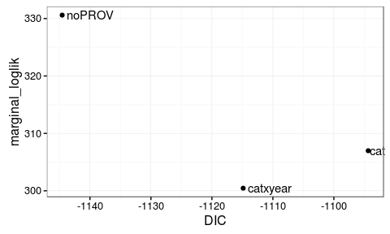

Relative performance of models. The reference model without genetic and spatio-temporal effects is off the scale.

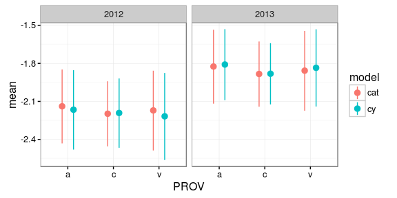

Baseline effect of the Provenance by Year and model in the latent scale.

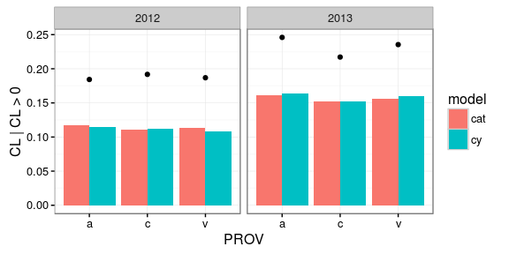

Baseline effect of the Provenance by Year and model in the probability scale. The black dots are the observed proportions of zeros.

The provenance is clearly irrelevant.

## 2.3 Role of the Bud-flush

Here we test the relevance of the Bud-flush in explaining the Binary component.

```
$ref

Call:
c("inla(formula = yt ~ 0 + BF98 + Year2013, family = \"gamma\", data = ml$cont$dat, ",  "    control.compute = list(dic = TRUE, waic = TRUE, cpo = TRUE, ",  "        po = TRUE, config = TRUE), control.fixed = list(expand.factor.strategy = \"inla\"), ",  "    inla.call = \"submit\")")

Time used:
 Pre-processing    Running inla Post-processing           Total
         0.1598          0.0496          0.0000          0.2094

Fixed effects:
            mean     sd 0.025quant 0.5quant 0.975quant    mode kld
BF981    -1.5389 0.2333    -1.9724  -1.5481    -1.0545 -1.5669   0
BF982    -1.7990 0.1400    -2.0654  -1.8020    -1.5151 -1.8082   0
BF983    -1.5709 0.1003    -1.7645  -1.5721    -1.3706 -1.5745   0
BF984    -1.5408 0.0848    -1.7050  -1.5417    -1.3719 -1.5433   0
BF985    -1.6807 0.0683    -1.8129  -1.6813    -1.5447 -1.6827   0
Year2013  0.1374 0.0729    -0.0069   0.1377     0.2796  0.1384   0

The model has no random effects

Model hyperparameters:
                                                mean     sd 0.025quant
Precision parameter for the Gamma observations 1.276 0.0617      1.158
                                               0.5quant 0.975quant  mode
Precision parameter for the Gamma observations    1.275      1.401 1.272

Expected number of effective parameters(std dev): 6.014(6e-04)
Number of equivalent replicates : 115.56

Deviance Information Criterion (DIC) ...: -737.98
Effective number of parameters .........: 6.649

Watanabe-Akaike information criterion (WAIC) ...: -737.55
Effective number of parameters .................: 6.911

Marginal log-Likelihood:  334.09
CPO and PIT are computed

Posterior marginals for linear predictor and fitted values computed


$noBF

Call:
c("inla(formula = ml$cont$fml, family = \"gamma\", data = inla.stack.data(ml$cont$stk), ",  "    control.compute = list(dic = TRUE, waic = TRUE, cpo = TRUE, ",  "        po = TRUE, config = TRUE), control.predictor = list(A = inla.stack.A(ml$cont$stk), ",  "        compute = TRUE, link = 1), control.family = list(hyper = list(theta = prec.od)), ",  "    control.fixed = list(expand.factor.strategy = \"inla\"), inla.call = \"submit\")" )

Time used:
 Pre-processing    Running inla Post-processing           Total
         0.5380          0.0491          0.0000          0.5871

Fixed effects:
                 mean     sd 0.025quant 0.5quant 0.975quant    mode kld
Year.cont2012 -2.1664 0.0731    -2.3093  -2.1668    -2.0211 -2.1677   0
Year.cont2013 -1.8191 0.0543    -1.9246  -1.8197    -1.7100 -1.8209   0

Random effects:
Name      Model
 theta.cont   SPDE2 model
recode.cont   Generic0 model

Model hyperparameters:
                                                  mean     sd 0.025quant
Precision parameter for the Gamma observations  2.9407 0.2619     2.4547
Theta1 for theta.cont                          -0.5767 0.3491    -1.2442
Theta2 for theta.cont                           1.0058 0.6213    -0.1820
GroupRho for theta.cont                         0.6703 0.3075    -0.1781
Precision for recode.cont                       1.8707 0.2372     1.4601
                                               0.5quant 0.975quant    mode
Precision parameter for the Gamma observations   2.9314     3.4829  2.9153
Theta1 for theta.cont                           -0.5845     0.1262 -0.6078
Theta2 for theta.cont                            0.9915     2.2600  0.9491
GroupRho for theta.cont                          0.7718     0.9791  0.9453
Precision for recode.cont                        1.8509     2.3897  1.8078

Expected number of effective parameters(std dev): 293.32(21.10)
Number of equivalent replicates : 2.369

Deviance Information Criterion (DIC) ...: -1144.55
Effective number of parameters .........: 288.49

Watanabe-Akaike information criterion (WAIC) ...: -1138.10
Effective number of parameters .................: 231.41

Marginal log-Likelihood:  330.56
CPO and PIT are computed

Posterior marginals for linear predictor and fitted values computed


$cat

Call:
c("inla(formula = update(ml$cont$fml, ~BF98.cont + Year2013.cont + ",  "    . - Year.cont), family = \"gamma\", data = inla.stack.data(ml$cont$stk), ",  "    control.compute = list(dic = TRUE, waic = TRUE, cpo = TRUE, ",  "        po = TRUE, config = TRUE), control.predictor = list(A = inla.stack.A(ml$cont$stk), ",  "        compute = TRUE, link = 1), control.family = list(hyper = list(theta = prec.od)), ",  "    control.fixed = list(expand.factor.strategy = \"inla\"), inla.call = \"submit\")" )

Time used:
 Pre-processing    Running inla Post-processing           Total
         0.5828          0.0478          0.0001          0.6307

Fixed effects:
                 mean     sd 0.025quant 0.5quant 0.975quant    mode kld
BF98.cont1    -1.9719 0.2967    -2.5489  -1.9740    -1.3836 -1.9782   0
BF98.cont2    -2.1976 0.1775    -2.5444  -2.1983    -1.8474 -2.1996   0
BF98.cont3    -1.9733 0.1233    -2.2137  -1.9739    -1.7294 -1.9751   0
BF98.cont4    -1.9608 0.1077    -2.1694  -1.9618    -1.7465 -1.9636   0
BF98.cont5    -2.1161 0.0914    -2.2922  -2.1172    -1.9330 -2.1193   0
Year2013.cont  0.2625 0.0749     0.1097   0.2644     0.4048  0.2677   0

Random effects:
Name      Model
 theta.cont   SPDE2 model
recode.cont   Generic0 model

Model hyperparameters:
                                                  mean     sd 0.025quant
Precision parameter for the Gamma observations  2.3794 0.1954     2.0465
Theta1 for theta.cont                          -0.3976 0.3805    -1.1153
Theta2 for theta.cont                           1.0505 0.5902    -0.0363
GroupRho for theta.cont                         0.6860 0.3060    -0.1739
Precision for recode.cont                       1.9548 0.2948     1.4106
                                               0.5quant 0.975quant    mode
Precision parameter for the Gamma observations   2.3603     2.8096  2.3136
Theta1 for theta.cont                           -0.4102     0.3793 -0.4466
Theta2 for theta.cont                            1.0210     2.2785  0.9361
GroupRho for theta.cont                          0.7912     0.9815  0.9525
Precision for recode.cont                        1.9457     2.5631  1.9393

Expected number of effective parameters(std dev): 269.98(22.26)
Number of equivalent replicates : 2.574

Deviance Information Criterion (DIC) ...: -1079.94
Effective number of parameters .........: 239.10

Watanabe-Akaike information criterion (WAIC) ...: -1052.30
Effective number of parameters .................: 213.09

Marginal log-Likelihood:  285.57
CPO and PIT are computed

Posterior marginals for linear predictor and fitted values computed


$catxyear

Call:
c("inla(formula = update(ml$cont$fml, ~. - Year.cont + Year.cont:BF98.cont), ",  "    family = \"gamma\", data = inla.stack.data(ml$cont$stk), control.compute = list(dic = TRUE, ",  "        waic = TRUE, cpo = TRUE, po = TRUE, config = TRUE), control.predictor = list(A = inla.stack.A(ml$cont$stk), ",  "        compute = TRUE, link = 1), control.family = list(hyper = list(theta = prec.od)), ",  "    control.fixed = list(expand.factor.strategy = \"inla\"), inla.call = \"submit\")" )

Time used:
 Pre-processing    Running inla Post-processing           Total
         0.5819          0.0472          0.0000          0.6291

Fixed effects:
                            mean     sd 0.025quant 0.5quant 0.975quant
Year.cont2012:BF98.cont1 -1.8520 0.3954    -2.6068  -1.8597    -1.0524
Year.cont2013:BF98.cont1 -1.7741 0.3085    -2.3699  -1.7777    -1.1580
Year.cont2012:BF98.cont2 -2.2362 0.2321    -2.6847  -2.2388    -1.7730
Year.cont2013:BF98.cont2 -1.9291 0.1776    -2.2739  -1.9306    -1.5765
Year.cont2012:BF98.cont3 -2.1056 0.1617    -2.4193  -2.1070    -1.7842
Year.cont2013:BF98.cont3 -1.6802 0.1114    -1.8971  -1.6808    -1.4596
Year.cont2012:BF98.cont4 -2.1413 0.1263    -2.3869  -2.1422    -1.8909
Year.cont2013:BF98.cont4 -1.6353 0.0967    -1.8227  -1.6362    -1.4427
Year.cont2012:BF98.cont5 -2.0901 0.0987    -2.2816  -2.0910    -1.8938
Year.cont2013:BF98.cont5 -1.8673 0.0764    -2.0141  -1.8684    -1.7137
                            mode kld
Year.cont2012:BF98.cont1 -1.8752   0
Year.cont2013:BF98.cont1 -1.7848   0
Year.cont2012:BF98.cont2 -2.2439   0
Year.cont2013:BF98.cont2 -1.9335   0
Year.cont2012:BF98.cont3 -2.1098   0
Year.cont2013:BF98.cont3 -1.6822   0
Year.cont2012:BF98.cont4 -2.1438   0
Year.cont2013:BF98.cont4 -1.6378   0
Year.cont2012:BF98.cont5 -2.0926   0
Year.cont2013:BF98.cont5 -1.8703   0

Random effects:
Name      Model
 theta.cont   SPDE2 model
recode.cont   Generic0 model

Model hyperparameters:
                                                  mean     sd 0.025quant
Precision parameter for the Gamma observations  2.4031 0.2021     2.0658
Theta1 for theta.cont                          -0.4003 0.3739    -1.1064
Theta2 for theta.cont                           1.0356 0.5866    -0.0490
GroupRho for theta.cont                         0.6589 0.3304    -0.2657
Precision for recode.cont                       1.9157 0.2960     1.3567
                                               0.5quant 0.975quant    mode
Precision parameter for the Gamma observations   2.3806     2.8553  2.3246
Theta1 for theta.cont                           -0.4119     0.3602 -0.4456
Theta2 for theta.cont                            1.0087     2.2503  0.9317
GroupRho for theta.cont                          0.7745     0.9789  0.9458
Precision for recode.cont                        1.9130     2.5092  1.9278

Expected number of effective parameters(std dev): 275.80(22.74)
Number of equivalent replicates : 2.52

Deviance Information Criterion (DIC) ...: -1094.00
Effective number of parameters .........: 239.76

Watanabe-Akaike information criterion (WAIC) ...: -1062.39
Effective number of parameters .................: 216.37

Marginal log-Likelihood:  271.24
CPO and PIT are computed

Posterior marginals for linear predictor and fitted values computed
```

|  | DIC | WAIC | marginal_loglik | LPML |
| --- | --- | --- | --- | --- |
| ref | -738 | -738 | 334 | 369 |
| noBF | -1145 | -1138 | 331 | 311 |
| cat | -1080 | -1052 | 286 | 313 |
| catxyear | -1094 | -1062 | 272 | 313 |

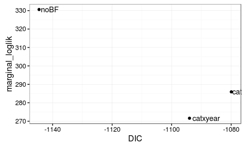

Relative performance of models. The reference model without genetic and spatio-temporal effects is off the scale.

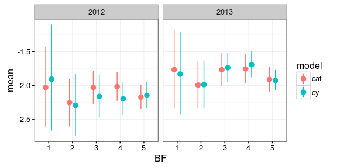

Baseline effect of the Bud flush by Year and model in the latent scale.

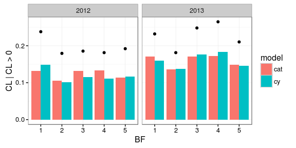

Baseline effect of the Bud flush by Year and model in the probability scale. The black dots are the observed proportions of zeros.

Absolutely irrelevant.

## 2.4 Model selection continuous component

We have analysed the effects of the Basal Circumference (BC), the Provenance (PROV) and the Bud-flushing (BF) separately, on the continuous variable `CL | CL > 0`.

In all three cases, there is no evidence of a relationship between these variables and the response. We are not including them in the continous component of the model.

# 3 Mixture spatio-temporal model

For a measurement of CL $y_{ijk}$ taken in year $i$, at the location $j$ for the individual $k$, we assume that \begin{equation} \begin{aligned} \text{Pr}[y_{ijk} = 0]& = p_{ijk}, && \quad 0 < p_{ijk} < 1 \\ \pi(y_{ijk} | y_{ijk} > 0)& = \text{Ga}(a_{ijk}, b_{ijk}), && \quad a_{ijk}, b_{ijk} > 0. \end{aligned} \end{equation} Or, equivalently, that the probability density of the response variable is \begin{equation} \pi(y | p, \alpha, \beta) = p \delta_0 + (1-p) \text{Ga}(y | a, b) I_{[y > 0]}, \end{equation}

where $\delta_0$ is the Dirac delta function

This can be seen as a semi-continuous model for the observed data, built as a mixture of a Bernoulli distribution which gives the pattern of zeros and a Gamma distribution for the positive values. We define a hierarchical model for the parameters $p$, $a$ and $b$ using appropriate link functions of the expected values of the respective distributions. Specifically, calling $\mu = E(y | y > 0) = \frac{a}{b}$, we define two linear predictors \begin{equation} \begin{split} \text{logit}(p_{ijk}) & = \text{X}_{ik}^{(1)} \beta^{(1)} + s_{ij}^{(1)} + a_k^{(1)}\\ \text{log}(\mu_{ijk}) & = \text{X}_{ik}^{(2)} \beta^{(2)}+ s_{ij}^{(2)} + a_k^{(2)}. \end{split} \end{equation}

where $\text{X}_{ij}^{(\cdot)}$ are matrices with explanatory covariates specific for each linear predictor potentially depending on the year and the individual; $s_{ij}$ is a structured spatio-temporal random effect and $a_k$ is an structured additive-genetic random effect at individual level.

The spatio-temporal structure is built as the Kronecker product of separate temporal and spatial zero-mean Gaussian processes. The temporal process is simply defined by a correlation parameter $\rho_t$ between consecutive observations, while the spatial process is defined by a Matérn covariance function with parameters of shape (or smoothness) $\nu$, spatial scale $\kappa$ and precision (i.e. inverse variance) $\tau$. The smoothness parameter is fixed to $\nu = 1$ for convenience. The spatial scale parameter is associated with the effective range of the spatial process, so that the correlation between locations at a distance $\rho_s = \sqrt{8}/\kappa$ is approximately $0.13$. Finally, the marginal variance of the spatial process is given by $\sigma_s^2 = (4 \pi\kappa^2\tau^2)^{-1}$.

Finally, the structured additive-genetic effect follows a zero-mean multivariate Normal distribution with a known covariance structure given by the family kinship. Specifically, the covariance matrix is $G = \sigma_a^2 A$, where $\sigma_a^2$ is the additive genetic variance in the base population and the additive-genetic structure matrix $A$ has elements $A_{kk'} = 2 \Theta_{kk'}$; i.e., twice the coefficient of coancestry between the individuals $k$ and $k'$ (see for example, Lynch and Walsh 1998, p. 756).

The results from this mixture model are equivalent to those obtained by running two separate models, one for each component. The difference is in the evaluation of the likelihood and other measures like DIC and WAIC. Running both models jointly allows for model comparison with other settings.

## 3.1 Model summary

```
Call:
c("inla(formula = ml$mst$fml, family = list(\"binomial\", \"gamma\"), ",  "    data = inla.stack.data(ml$mst$stk), Ntrials = 1, control.compute = list(dic = TRUE, ",  "        waic = TRUE, cpo = TRUE, po = TRUE, config = TRUE), control.predictor = list(A = inla.stack.A(ml$mst$stk), ",  "        compute = TRUE, link = link.NA), control.family = list(list(), ",  "        list(hyper = list(theta = prec.od))), control.inla = list(correct = TRUE, ",  "        correct.factor = 10), control.fixed = list(expand.factor.strategy = \"inla\"), ",  "    inla.call = \"submit\")")

Time used:
 Pre-processing    Running inla Post-processing           Total
         0.7617          0.0409          0.0001          0.8026

Fixed effects:
                 mean     sd 0.025quant 0.5quant 0.975quant    mode kld
Year.bin2012   1.9516 0.2276     1.5438   1.9374     2.4207  1.8911   0
Year.bin2013  -0.5725 0.1709    -0.9112  -0.5721    -0.2371 -0.5719   0
Year.cont2012 -2.1644 0.0716    -2.3037  -2.1650    -2.0222 -2.1661   0
Year.cont2013 -1.8186 0.0526    -1.9206  -1.8192    -1.7133 -1.8204   0

Random effects:
Name      Model
 theta.bin   SPDE2 model
recode.bin   Generic0 model
theta.cont   SPDE2 model
recode.cont   Generic0 model

Model hyperparameters:
                                                     mean     sd
Precision parameter for the Gamma observations[2]  2.9298 0.2570
Theta1 for theta.bin                               0.9555 0.2963
Theta2 for theta.bin                               0.8769 0.3990
GroupRho for theta.bin                             0.9362 0.0824
Precision for recode.bin                           0.2100 0.0531
Theta1 for theta.cont                             -0.5443 0.4450
Theta2 for theta.cont                              1.2287 0.6761
GroupRho for theta.cont                            0.6102 0.3096
Precision for recode.cont                          1.8548 0.2409
                                                  0.025quant 0.5quant
Precision parameter for the Gamma observations[2]     2.4528   2.9209
Theta1 for theta.bin                                  0.3911   0.9482
Theta2 for theta.bin                                  0.1391   0.8583
GroupRho for theta.bin                                0.7088   0.9634
Precision for recode.bin                              0.1254   0.2034
Theta1 for theta.cont                                -1.4158  -0.5454
Theta2 for theta.cont                                -0.0873   1.2243
GroupRho for theta.cont                              -0.2148   0.7033
Precision for recode.cont                             1.4355   1.8356
                                                  0.975quant    mode
Precision parameter for the Gamma observations[2]     3.4610  2.9056
Theta1 for theta.bin                                  1.5543  0.9254
Theta2 for theta.bin                                  1.7006  0.7997
GroupRho for theta.bin                                0.9948  0.9868
Precision for recode.bin                              0.3325  0.1907
Theta1 for theta.cont                                 0.3319 -0.5486
Theta2 for theta.cont                                 2.5660  1.2103
GroupRho for theta.cont                               0.9530  0.8717
Precision for recode.cont                             2.3797  1.7950

Expected number of effective parameters(std dev): 702.00(39.85)
Number of equivalent replicates : 3.198

Deviance Information Criterion (DIC) ...: 353.76
Effective number of parameters .........: 645.96

Watanabe-Akaike information criterion (WAIC) ...: 303.24
Effective number of parameters .................: 479.57

Marginal log-Likelihood:  -661.16
CPO and PIT are computed

Posterior marginals for linear predictor and fitted values computed
```

`R-INLA` package version hgid: 8f358b6bbca2 date: Thu Sep 03 23:07:55 2015 +0200

## 3.2 Fitted vs. Observations

Note that the fact that the prediction is not *centered* around the observed values is a consequence of the discrete nature of the response variable. It would be unlikely to predict a value under 1 or above 3.16, when these are the extreme observed values.

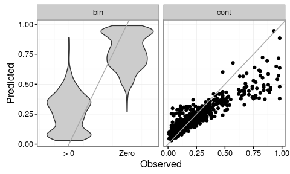

Fitted vs. observed values

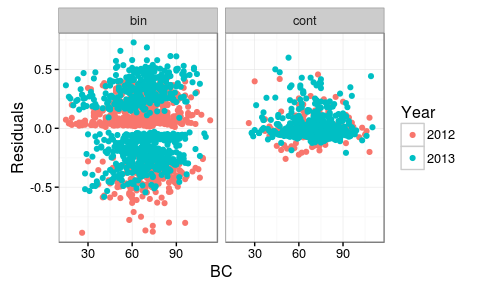

Residuals vs Basal Circumference.

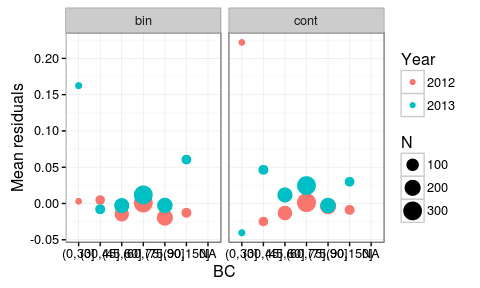

Mean of residuals by category of Basal Circumference.

It is certainly not evident at all from this diagnostics plot that there is a missing relationship between CL and BC. The strong differences for circumferences under 30 cm are based on very few points, and might well have arosen by chance.

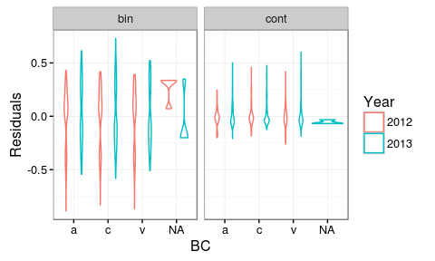

Residuals vs Provenance.

Nor for the case of the provenances.

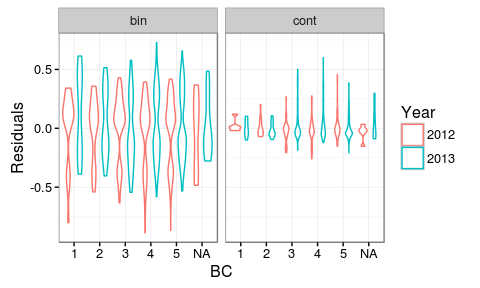

Residuals vs Bud flushing.

Nor for the flushing.

## 3.3 Genetic effects

Here we plot the posterior distribution for the individual breeding values. Family effect included implicitly.

Not very useful, isn’t it?

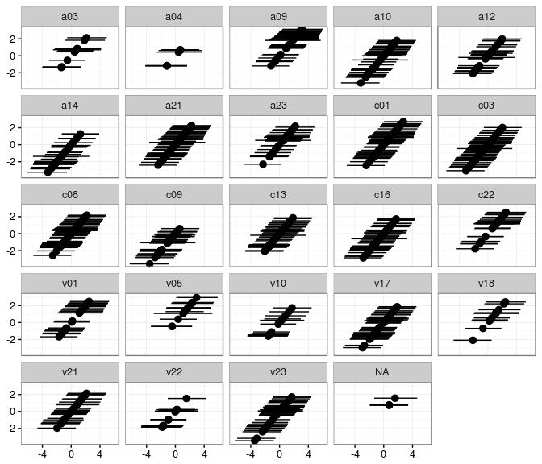

Posterior individual additive-genetic effects. Binary component.

## 3.4 Posterior distributions of spatial field’s characteristics

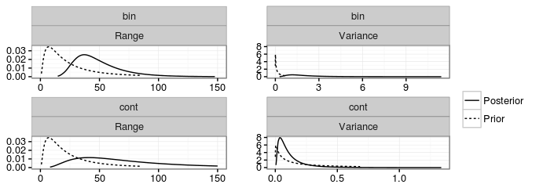

Prior and posterior densities for the spatio-temporal field characteristics.

## 3.5 Posterior spatiotemporal field

The surfaces for the years 2012 and 2013 are remarkably similar in both components. We should try a model with one single spatial effect for both years.

This indicates, unlike the Crown Dieback variable, that there is no spatial *spread* of this symptom.

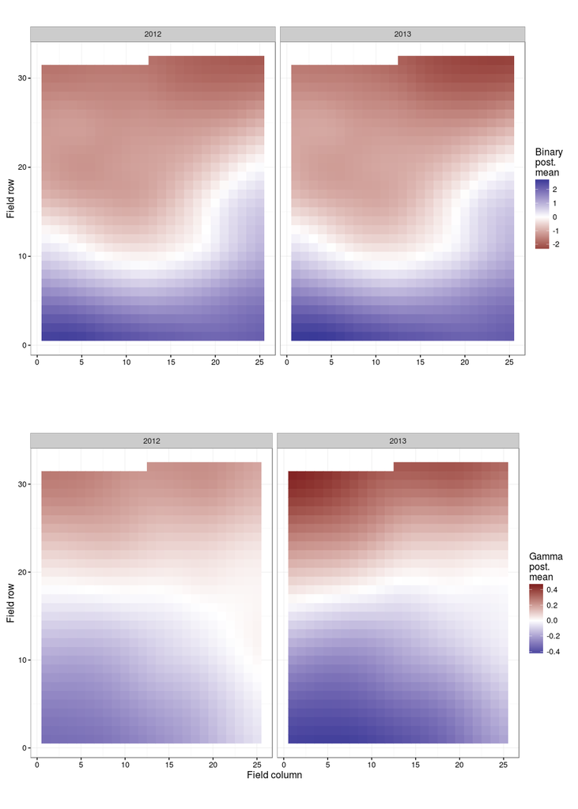

Posterior mean of the spatio-temporal field. Latent scale.

In the following figure we can see the mean posterior ST effect of both model components, by Year, in the original scale.

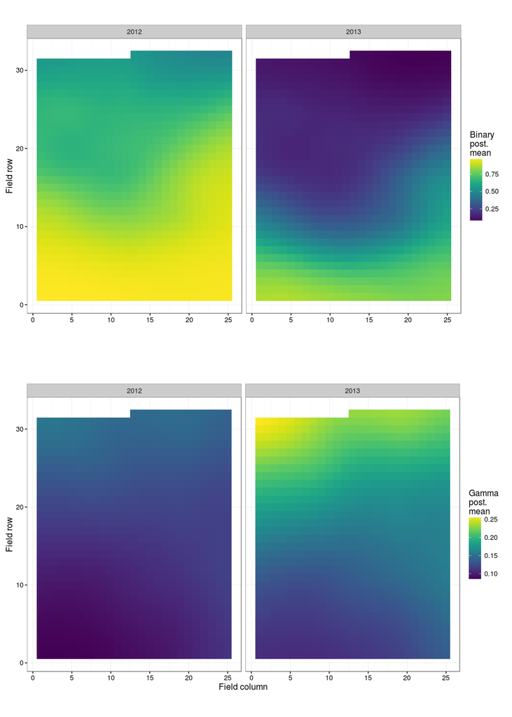

Posterior mean of the spatio-temporal field. Original scale.

## 3.6 Phenotype vs. Predicted Breeding Values (PBV)

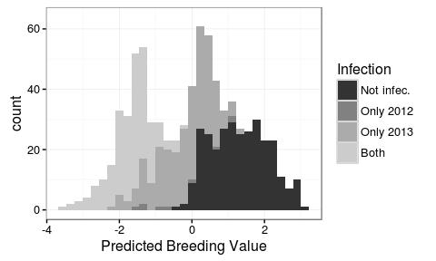

Distribution of PBV for the Binomial component of CL, by observed infection status.

## 3.7 Heritability

In principle, we have two heritabilities here, corresponding to two different traits: the first explains the pattern of the zeros, and the second explains the degree of infection, given that there is infection. Can be thought of like *resistance* and *sensitivity*.

Both with a Binomial and Gamma likelihoods, **the phenotypic variance is a function of the mean**, which means that it varies from observation to observation. Although the additive-genetic variance(s) is common to the population, the phenotypic variance can not be decomposed additively into genetic and residual components. In this context some funny things can take place. For example, a decrease in the phenotypic variance as a consequence of an increase in the genetic variance.

### 3.7.1 Heritability in the latent/observed scale

In order to compute the posterior density of the heritability, we sample from the posterior distributions of the hyperparameters of the model, and build a posterior sample of heritabilities with the formula (Nakagawa and Schielzeth 2010, Vazquez et al. (2009))
$$h^2 =
\frac{\sigma^2_a}{\sigma^2_a + \omega \pi^2/3},$$
where $\omega$ equals $1$ in the case of the Binary trait.

For the Gamma component, we followed the general approach described in (Villemereuil et al. 2015).

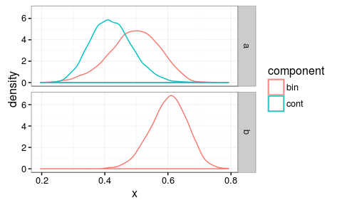

Posterior heritability by model component, including (a) or not (b) the spatio-temporal variance in the denominator.

I don’t have a good way of computing the heritability for the Gamma component excluding the ST variance. On the other hand, the approach by (Villemereuil et al. 2015) gave numerical issues for the binary compoent.

```
Source: local data frame [3 x 5]
Groups: component [?]

  component spatial_variance      mean      ymin      ymax
      (chr)            (chr)     (dbl)     (dbl)     (dbl)
1       bin                a 0.4932711 0.3218754 0.6369609
2       bin                b 0.6025712 0.4801233 0.7113447
3      cont                a 0.4220112 0.3005909 0.5627217
```

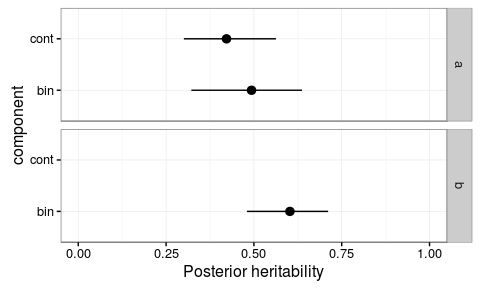

# 4 Conclusions

Here is a summary of the model comparison conducted separately for the binary and continuous components.

Model selection criteria for the binary component

| Model | Specificity | Linear.predictor | DIC | p_D | WAIC | p_W | Dev. |
| --- | --- | --- | --- | --- | --- | --- | --- |
| M0 | Reference | Year + *IBV* + *ST* | 1498 | 356 | 1443 | 249 | 1978 |
| M1.1 | BC categories | Year + BC + *IBV* + *ST* | 1485 | 368 | 1428 | 255 | 2014 |
| M1.2 | BC cat. x Year | Year * BC + *IBV* + *ST* | 1472 | 386 | 1410 | 264 | 2051 |
| M1.3 | BC linear | Year + $\beta$ BC + *IBV* + *ST* | 1494 | 361 | 1438 | 251 | 1988 |
| M1.4 | BC quadratic | Year + $\beta$ BC + $\beta$ BC^2 + *IBV* + *ST* | 1492 | 361 | 1436 | 251 | 1996 |
| M1.5 | BC non-parametric | Year + f(BC) + *IBV* + *ST* | 1494 | 360 | 1438 | 251 | 2254 |
| M2.1 | PROV | Year + PROV + *IBV* + *ST* | 1493 | 366 | 1434 | 253 | 1994 |
| M2.2 | PROV x Year | Year * PROV + *IBV* + *ST* | 1498 | 367 | 1441 | 254 | 2013 |

Model selection criteria for the continuous component

| Model | Specificity | Linear.predictor | DIC | p_D | WAIC | p_W | Dev. |
| --- | --- | --- | --- | --- | --- | --- | --- |
| M0.1 | Beta likelihood | BF98 + PROV + Year*BC | -603 | 26 | -607 | 20 | -368 |
| M0.2 | Gamma likelihood | BF98 + PROV + Year*BC | -771 | 26 | -767 | 28 | -525 |
| M0.3 | Reference | Year + *IBV* + *ST* | -1144 | 289 | -1138 | 232 | -661 |
| M1.1 | BC categories | Year + BC + *IBV* + *ST* | -1140 | 288 | -1133 | 231 | -616 |
| M1.2 | BC cat. x Year | Year * BC + *IBV* + *ST* | -1136 | 293 | -1131 | 234 | -573 |
| M1.3 | BC linear | Year + $\beta$ BC + *IBV* + *ST* | -1140 | 287 | -1133 | 231 | -650 |
| M1.4 | BC quadratic | Year + $\beta$ BC + $\beta$ BC^2 + *IBV* + *ST* | -1140 | 288 | -1134 | 231 | -638 |
| M1.5 | BC non-parametric | Year + f(BC) + *IBV* + *ST* | -1143 | 290 | -1136 | 233 | -379 |
| M2.1 | PROV | Year + PROV + *IBV* + *ST* | -1094 | 316 | -1112 | 234 | -614 |
| M2.2 | PROV x Year | Year * PROV + *IBV* + *ST* | -1115 | 286 | -1107 | 231 | -601 |

# References

Nakagawa, Shinichi, and Holger Schielzeth. 2010. “Repeatability for Gaussian and non-Gaussian Data: A Practical Guide for Biologists.” *Biological Reviews* 85 (4). Blackwell Publishing Ltd: 935–56. doi:10.1111/j.1469-185x.2010.00141.x.

Vazquez, A. I., D. Gianola, D. Bates, K. A. Weigel, and B. Heringstad. 2009. “Assessment of Poisson, Logit, and Linear Models for Genetic Analysis of Clinical Mastitis in Norwegian Red Cows.” *Journal of Dairy Science* 92 (2): 739–48. doi:10.3168/jds.2008-1325.

Villemereuil, Pierre de, Holger Schielzeth, Shinichi Nakagawa, and Michael Morrissey. 2015. “General Methods for Evolutionary Quantitative Genetic Inference from Generalised Mixed Models.” *BioRxiv*, September. Cold Spring Harbor Labs Journals, 026377+. doi:10.1101/026377.